# FIA - NLS Models: Biomass Growth vs. Biomass - Temporally-Balanced, No harvest

JAH

2022-10-25

This document has nls (non-linear least squares) regression fits using the Michaelis-Menten functional form to USFS FIA (United States Forest Service Forest Inventory & Analysis) **biomass growth vs. biomass** relationships. We use the sum of tree biomass growth increment method for the plot biomass growth ($G$) calculation (see supplementary methods). Models are fitted separately by US ecoprovince

Data have increasing variance in $G$ with increasing $B$, Thus, weighted nls is the best approach. We explore a few weighting options and found that proportional weighting can be achieved by weighting observations by $\frac {1} {meanG}$ in equal-sample sized plot biomass bins (n=20) for each ecoprovince.

Model selection is used to determine. to determine the best fitting models, which is implemented in two parts. A first model selection is done to determine the best model form either including $\alpha$: the biomass compensation effect due to lost biomass (natural mortality or harvest), $\phi$: the effect of changing climate (quantified as $\Delta PDSI$, or both. $\Delta PDSI$ is defined the difference in the Palmer drought severity index from January - August for the 10 years preceding the biomass measurement and the 1969-1990 period). We explored $\Delta PDSI$ using only the summer growing months (June-August) over the same intervals, and analyses were insensitive to that change. For the first model selection the following models are considered:

**model 1: simple model** $G = (1 + (yr-1990)* ge/100) \times \left( \frac {A \cdot B_{t1}} {k+B_{t1}} \right)$

**model 2: phi model** $G = (1 + (yr-1990)* ge/100) \times (1 + \phi \cdot \Delta PDSI) \times \left( \frac {A \cdot B_{t1}} {k+B_{t1}} \right)$

**model 3: phi-alpha model** $G = (1 + (yr-1990)* ge/100) \times (1 + \phi \cdot \Delta PDSI) \times (1 - \alpha \cdot B_l) \times \left( \frac {A \cdot B_{t1}} {k+B_{t1}} \right)$

Then, a second model selection is done using best-fitting model from part 1 and then considering additional $p$ and $s$ parameters (individually, and then together) to modify the Micheaelis-Menten functional form. The $p$ parameter allows for an intercept in the model (i.e., for the model to not be forced through the origin), and the $s$ parameter increases model flexibility, with $s$>1 leading to more-sigmoidal shape.

**sub-model a: p form** $pA + \left( \frac {(1-p)A \cdot B_{t1}} {k+B_{t1}} \right)$

**sub model b: s form** $\left( \frac {A \cdot B_{t1}^s} {k^s+B_{t1}^s} \right)$

**sub model c: p and s together** $pA + \left( \frac {(1-p)A \cdot B_{t1}^s} {k^s+B_{t1}^s} \right)$

*NOTE:*

*This document contains a temporally balanced set of $G$ observations. First, the data set limited to plots that meet our plot-based filtering criteria (see below). Then the data set was further restricted to plots with at least 2 $G$ observations (i.e., three FIA tree census records), with one in each of the two following decades: 2000-2010 (including censuses part of FIA 3.0 from 1996-2000 as part of the 2000 panel), and 2011-2022. For plots that had >2 $G$ observations we took the first and last ones.*

1. exclude FIA plots in plantation forests
2. exclude FIA plots with multiple plot conditions (COND_PROP_UNADJ > 0.95)
3. exclude FIA plots non-productive stands (i.e., those with less than 20 ft^3/acre/year timber producing capability; SITECLCD of 7)
4. exclude FIA plots in non-stocked stands (i.e., those with STDSZCD of 5)
5. exclude FIA plots in non-accessible areas (i.e., private lands etc., COND_STATUS_CD not equal to 1)
6. exclude FIA plot visits that are not part of the annual inventories (which also includes FIA plot visits for Phase 3 ozone measurements)

Additionally, in an effort to clean up the data set, we have removed outlier observations, using a quantile threshold approach. We also calculated plot $G$ using as biomass balance method (see supplementary methods), and the difference between the two methods. Accordingly, we define $diff_G$ as the difference between tree incremental $G$ and biomass balance $G$. We excluded observations which meet the following criteria using a 0.5% quantile ($QT$):

- case A: where the $QT$ difference in tree incremental $G$ is > biomass balance plot G (i.e., > 99.5% $diff_G$ positive outliers)
- case B: where the $QT$ difference in tree incremental $G$ is < mass balance plot G (i.e., < 0.5% $diff_G$ negative outliers)
- case C: where the $QT$ difference in tree incremental $G$ is > 0 (i.e., > 99.5% positive outliers)
- case D: where the $QT$ difference in tree incremental $G$ is > 0 (i.e., < 0.5% negative outliers)

These data set cleaning criteria resulted in the exclusion of 1677 observations.

Below the model fitting procedure is implemented by ecoprovince:

# Temporally-balancing the biomass growth data set

Lets look at some quick attributes of the dataset

- The data set has 104986 observations, comprised of 55492 plots.
- The frequency of growth measurements among plots is as follows : 25149, 13819, 13897, 2627.
- Thus 54.68 % of plots have at least two growth intervals.

# 211 - Northeastern Mixed Forest

## model selection 1

```
## Analysis of Variance Table
##
## Model 1: G_obs_TreeInc_MgHaYr ~ (1 + (MEASTIME_avg - 1990) * ge/100) * A * B_plt_t1_MgHa/(k + B_plt_t1_MgHa)
## Model 2: G_obs_TreeInc_MgHaYr ~ (1 + (MEASTIME_avg - 1990) * ge/100) * (1 + phi * DeltaPDSI) * A * B_plt_t1_MgHa/(k + B_plt_t1_MgHa)
## Model 3: G_obs_TreeInc_MgHaYr ~ (1 + (MEASTIME_avg - 1990) * ge/100) * (1 + phi * DeltaPDSI) * (1 - alpha * B_L_prop) * A * B_plt_t1_MgHa/(k + B_plt_t1_MgHa)
##   Res.Df Res.Sum Sq Df  Sum Sq F value    Pr(>F)
## 1   3710     2628.1
## 2   3709     2627.4  1  0.6876  0.9707    0.3246
## 3   3708     2604.2  1 23.1247 32.9256 1.034e-08 ***
## ---
## Signif. codes:  0 '***' 0.001 '**' 0.01 '*' 0.05 '.' 0.1 ' ' 1
##   model      AIC
## 1     1 13465.03
## 2     2 13466.06
## 3     3 13435.24
```

```
##
## Formula: G_obs_TreeInc_MgHaYr ~ (1 + (MEASTIME_avg - 1990) * ge/100) *
##     (1 + phi * DeltaPDSI) * (1 - alpha * B_L_prop) * A * B_plt_t1_MgHa/(k +
##     B_plt_t1_MgHa)
##
## Parameters:
##        Estimate Std. Error t value Pr(>|t|)
## ge     0.041924   0.179101   0.234    0.815
## phi    0.005103   0.005678   0.899    0.369
## alpha  0.522630   0.087462   5.976 2.51e-09 ***
## A      3.650326   0.133308  27.383  < 2e-16 ***
## k     10.044303   0.925040  10.858  < 2e-16 ***
## ---
## Signif. codes:  0 '***' 0.001 '**' 0.01 '*' 0.05 '.' 0.1 ' ' 1
##
## Residual standard error: 0.8381 on 3708 degrees of freedom
##
## Number of iterations to convergence: 6
## Achieved convergence tolerance: 2.876e-06
##   (1 observation deleted due to missingness)
```

### summary

- simple model: fits
- phi model: fits
- phi-alpha model: fits

## model selection 2

```
## Analysis of Variance Table
##
## Model 1: G_obs_TreeInc_MgHaYr ~ (1 + (MEASTIME_avg - 1990) * ge/100) * (1 + phi * DeltaPDSI) * (1 - alpha * B_L_prop) * A * B_plt_t1_MgHa/(k + B_plt_t1_MgHa)
## Model 2: G_obs_TreeInc_MgHaYr ~ (1 + (MEASTIME_avg - 1990) * ge/100) * (1 + phi * DeltaPDSI) * (1 - alpha * B_L_prop) * (p * A + ((1 - p) * A * B_plt_t1_MgHa/(k + B_plt_t1_MgHa)))
## Model 3: G_obs_TreeInc_MgHaYr ~ (1 + (MEASTIME_avg - 1990) * ge/100) * (1 + phi * DeltaPDSI) * (1 - alpha * B_L_prop) * (A * B_plt_t1_MgHa^s/(k^s + B_plt_t1_MgHa^s))
## Model 4: G_obs_TreeInc_MgHaYr ~ (1 + (MEASTIME_avg - 1990) * ge/100) * (1 + phi * DeltaPDSI) * (1 - alpha * B_L_prop) * (p * A + ((1 - p) * A * B_plt_t1_MgHa^s/(k^s + B_plt_t1_MgHa^s)))
##   Res.Df Res.Sum Sq Df  Sum Sq F value  Pr(>F)
## 1   3708     2604.2
## 2   3707     2602.2  1 2.09054  2.9782 0.08448 .
## 3   3707     2602.6  0 0.00000
## 4   3706     2602.2  1 0.41181  0.5865 0.44382
## ---
## Signif. codes:  0 '***' 0.001 '**' 0.01 '*' 0.05 '.' 0.1 ' ' 1
##   model      AIC
## 1     3 13435.24
## 2    3a 13434.26
## 3    3b 13434.84
## 4    3c 13436.25
```

```
##
## Formula: G_obs_TreeInc_MgHaYr ~ (1 + (MEASTIME_avg - 1990) * ge/100) *
##     (1 + phi * DeltaPDSI) * (1 - alpha * B_L_prop) * (p * A +
##     ((1 - p) * A * B_plt_t1_MgHa/(k + B_plt_t1_MgHa)))
##
## Parameters:
##        Estimate Std. Error t value Pr(>|t|)
## ge     0.039038   0.178842   0.218   0.8272
## phi    0.004869   0.005675   0.858   0.3909
## alpha  0.517067   0.087404   5.916 3.60e-09 ***
## A      3.701535   0.140568  26.333  < 2e-16 ***
## k     13.465734   2.640734   5.099 3.58e-07 ***
## p      0.125089   0.066259   1.888   0.0591 .
## ---
## Signif. codes:  0 '***' 0.001 '**' 0.01 '*' 0.05 '.' 0.1 ' ' 1
##
## Residual standard error: 0.8378 on 3707 degrees of freedom
##
## Number of iterations to convergence: 4
## Achieved convergence tolerance: 4.739e-07
##   (1 observation deleted due to missingness)
```

### summary

- add p model: fits
- add s model: fits
- add s+p model: fits

## plot residuals

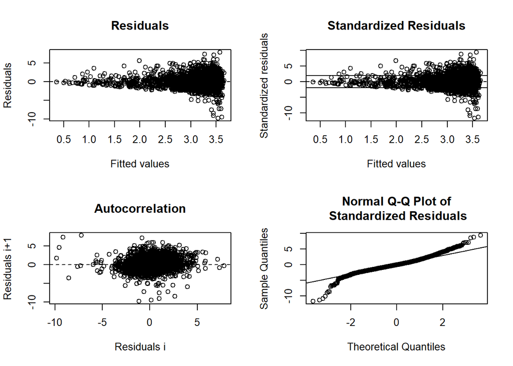

```
##
## ------
##  Shapiro-Wilk normality test
##
## data:  stdres
## W = 0.96547, p-value < 2.2e-16
##
##
## ------
```

```
##
##  Runs Test
##
## data:  as.factor(run)
## Standard Normal = -12.028, p-value < 2.2e-16
## alternative hypothesis: two.sided
```

## predict and plot

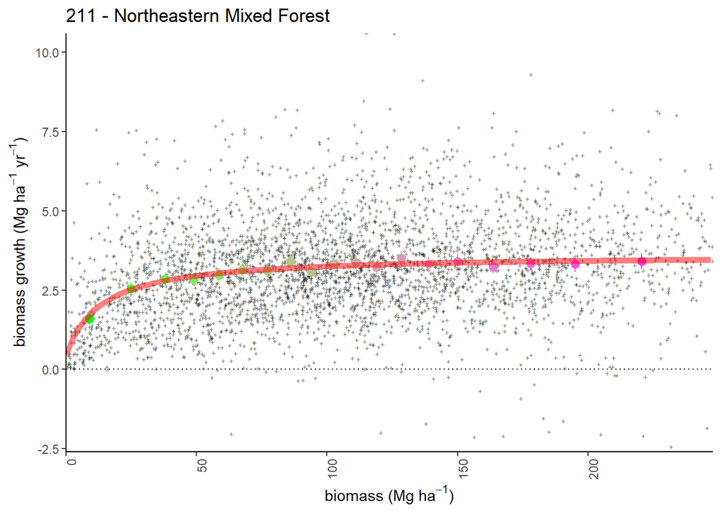

## plotting 2

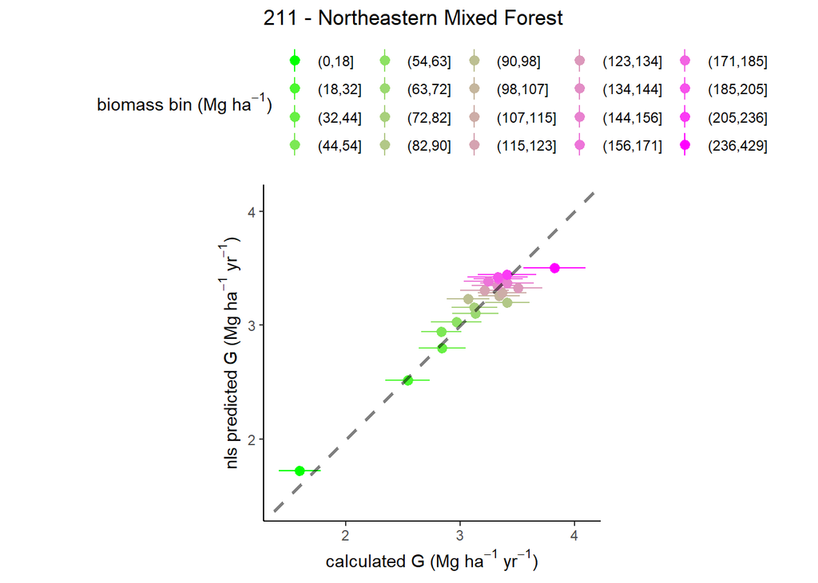

# 212 - Laurentian Mixed Forest

## model selection 1

[output not shown]

```
##
## Formula: G_obs_TreeInc_MgHaYr ~ (1 + (MEASTIME_avg - 1990) * ge/100) *
##     (1 + phi * DeltaPDSI) * (1 - alpha * B_L_prop) * A * B_plt_t1_MgHa/(k +
##     B_plt_t1_MgHa)
##
## Parameters:
##       Estimate Std. Error t value Pr(>|t|)
## ge     0.35087    0.14564   2.409    0.016 *
## phi    0.02401    0.00412   5.828 5.78e-09 ***
## alpha  0.59613    0.04946  12.053  < 2e-16 ***
## A      3.04834    0.08687  35.092  < 2e-16 ***
## k     16.01318    0.74106  21.609  < 2e-16 ***
## ---
## Signif. codes:  0 '***' 0.001 '**' 0.01 '*' 0.05 '.' 0.1 ' ' 1
##
## Residual standard error: 0.872 on 9651 degrees of freedom
##
## Number of iterations to convergence: 5
## Achieved convergence tolerance: 9.377e-06
##   (2 observations deleted due to missingness)
```

### summary

- simple model: fits
- phi model: fits
- phi-alpha model: fits

## model selection 2

```
## Analysis of Variance Table
##
## Model 1: G_obs_TreeInc_MgHaYr ~ (1 + (MEASTIME_avg - 1990) * ge/100) * (1 + phi * DeltaPDSI) * (1 - alpha * B_L_prop) * A * B_plt_t1_MgHa/(k + B_plt_t1_MgHa)
## Model 2: G_obs_TreeInc_MgHaYr ~ (1 + (MEASTIME_avg - 1990) * ge/100) * (1 + phi * DeltaPDSI) * (1 - alpha * B_L_prop) * (p * A + ((1 - p) * A * B_plt_t1_MgHa/(k + B_plt_t1_MgHa)))
## Model 3: G_obs_TreeInc_MgHaYr ~ (1 + (MEASTIME_avg - 1990) * ge/100) * (1 + phi * DeltaPDSI) * (1 - alpha * B_L_prop) * (A * B_plt_t1_MgHa^s/(k^s + B_plt_t1_MgHa^s))
## Model 4: G_obs_TreeInc_MgHaYr ~ (1 + (MEASTIME_avg - 1990) * ge/100) * (1 + phi * DeltaPDSI) * (1 - alpha * B_L_prop) * (p * A + ((1 - p) * A * B_plt_t1_MgHa^s/(k^s + B_plt_t1_MgHa^s)))
##   Res.Df Res.Sum Sq Df Sum Sq F value    Pr(>F)
## 1   9651     7338.7
## 2   9650     7253.3  1 85.400 113.619 < 2.2e-16 ***
## 3   9650     7277.8  0  0.000
## 4   9649     7252.2  1 25.618  34.084 5.448e-09 ***
## ---
## Signif. codes:  0 '***' 0.001 '**' 0.01 '*' 0.05 '.' 0.1 ' ' 1
##   model      AIC
## 1     3 32610.78
## 2    3a 32499.75
## 3    3b 32532.26
## 4    3c 32500.22
```

```
##
## Formula: G_obs_TreeInc_MgHaYr ~ (1 + (MEASTIME_avg - 1990) * ge/100) *
##     (1 + phi * DeltaPDSI) * (1 - alpha * B_L_prop) * (p * A +
##     ((1 - p) * A * B_plt_t1_MgHa/(k + B_plt_t1_MgHa)))
##
## Parameters:
##        Estimate Std. Error t value Pr(>|t|)
## ge     0.323153   0.143289   2.255   0.0241 *
## phi    0.024115   0.004088   5.899 3.77e-09 ***
## alpha  0.556760   0.049380  11.275  < 2e-16 ***
## A      3.322911   0.105051  31.631  < 2e-16 ***
## k     32.009397   2.818093  11.359  < 2e-16 ***
## p      0.171000   0.013230  12.925  < 2e-16 ***
## ---
## Signif. codes:  0 '***' 0.001 '**' 0.01 '*' 0.05 '.' 0.1 ' ' 1
##
## Residual standard error: 0.867 on 9650 degrees of freedom
##
## Number of iterations to convergence: 4
## Achieved convergence tolerance: 4.977e-06
##   (2 observations deleted due to missingness)
```

### summary

- add p model: fits
- add s model: fits
- add s+p model: fits

## plot residuals

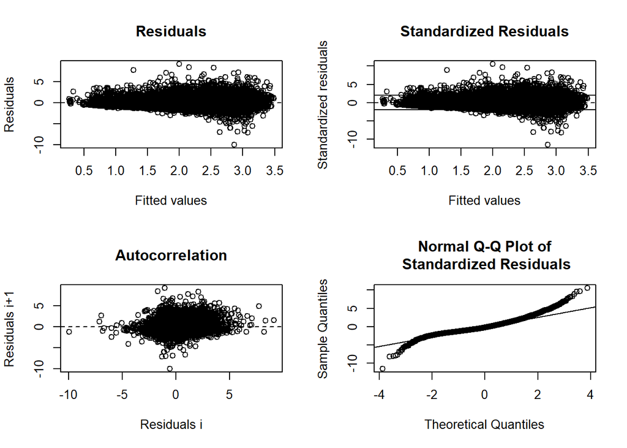

## predict and plot

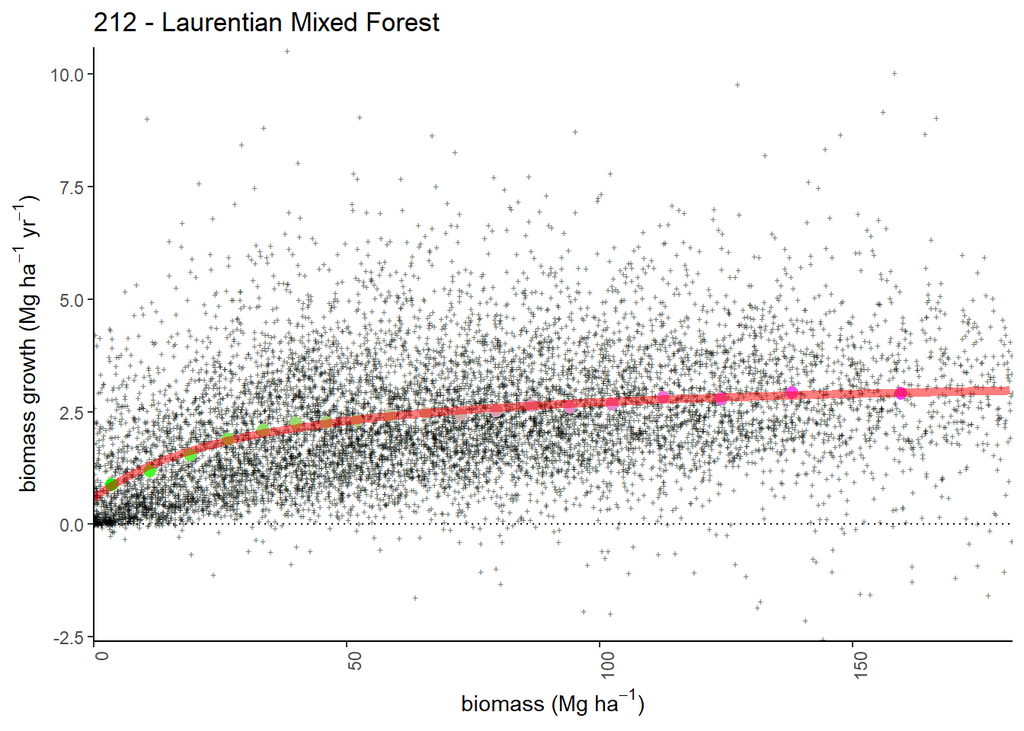

## plotting 2

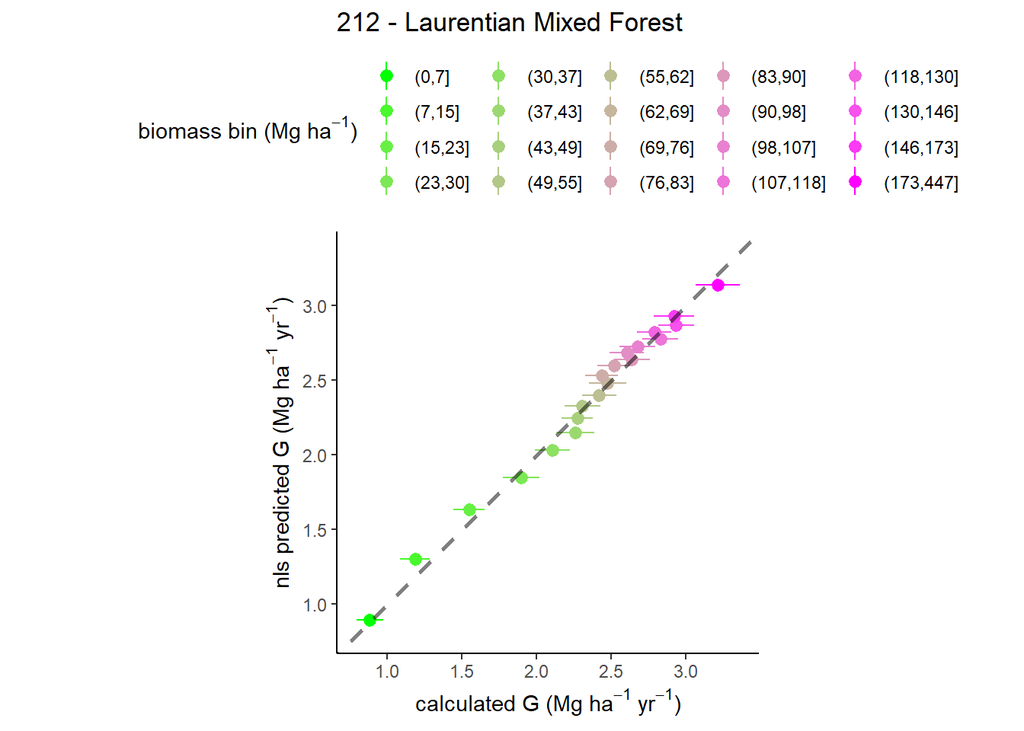

# 221 - Eastern Broadleaf Forest

## model selection 1

```
## Analysis of Variance Table
##
## Model 1: G_obs_TreeInc_MgHaYr ~ (1 + (MEASTIME_avg - 1990) * ge/100) * A * B_plt_t1_MgHa/(k + B_plt_t1_MgHa)
## Model 2: G_obs_TreeInc_MgHaYr ~ (1 + (MEASTIME_avg - 1990) * ge/100) * (1 + phi * DeltaPDSI) * A * B_plt_t1_MgHa/(k + B_plt_t1_MgHa)
## Model 3: G_obs_TreeInc_MgHaYr ~ (1 + (MEASTIME_avg - 1990) * ge/100) * (1 + phi * DeltaPDSI) * (1 - alpha * B_L_prop) * A * B_plt_t1_MgHa/(k + B_plt_t1_MgHa)
##   Res.Df Res.Sum Sq Df Sum Sq F value    Pr(>F)
## 1   4377     4692.6
## 2   4376     4692.6  1  0.002   0.002    0.9646
## 3   4375     4643.0  1 49.609  46.745 9.202e-12 ***
## ---
## Signif. codes:  0 '***' 0.001 '**' 0.01 '*' 0.05 '.' 0.1 ' ' 1
##   model      AIC
## 1     1 18398.17
## 2     2 18400.17
## 3     3 18355.62
```

```
##
## Formula: G_obs_TreeInc_MgHaYr ~ (1 + (MEASTIME_avg - 1990) * ge/100) *
##     (1 + phi * DeltaPDSI) * (1 - alpha * B_L_prop) * A * B_plt_t1_MgHa/(k +
##     B_plt_t1_MgHa)
##
## Parameters:
##        Estimate Std. Error t value Pr(>|t|)
## ge    -1.414091   0.102722 -13.766  < 2e-16 ***
## phi   -0.001078   0.006056  -0.178    0.859
## alpha  0.538863   0.076226   7.069  1.8e-12 ***
## A      6.309277   0.210723  29.941  < 2e-16 ***
## k     21.057421   2.284358   9.218  < 2e-16 ***
## ---
## Signif. codes:  0 '***' 0.001 '**' 0.01 '*' 0.05 '.' 0.1 ' ' 1
##
## Residual standard error: 1.03 on 4375 degrees of freedom
##
## Number of iterations to convergence: 6
## Achieved convergence tolerance: 9.533e-06
##   (6 observations deleted due to missingness)
```

### summary

- simple model: fits
- phi model: fits
- phi-alpha model: fits

## model selection 2

```
## Error in nls(get(paste("fg_", Mod.Sel1, "b", sep = "")), data = G_221,  :
##   number of iterations exceeded maximum of 50
## Error in nls(get(paste("fg_", Mod.Sel1, "c", sep = "")), data = G_221,  :
##   step factor 0.000488281 reduced below 'minFactor' of 0.000976562
## Analysis of Variance Table
##
## Model 1: G_obs_TreeInc_MgHaYr ~ (1 + (MEASTIME_avg - 1990) * ge/100) * (1 + phi * DeltaPDSI) * (1 - alpha * B_L_prop) * A * B_plt_t1_MgHa/(k + B_plt_t1_MgHa)
## Model 2: G_obs_TreeInc_MgHaYr ~ (1 + (MEASTIME_avg - 1990) * ge/100) * (1 + phi * DeltaPDSI) * (1 - alpha * B_L_prop) * (p * A + ((1 - p) * A * B_plt_t1_MgHa/(k + B_plt_t1_MgHa)))
##   Res.Df Res.Sum Sq Df Sum Sq F value    Pr(>F)
## 1   4375     4643.0
## 2   4374     4608.3  1 34.741  32.975 9.968e-09 ***
## ---
## Signif. codes:  0 '***' 0.001 '**' 0.01 '*' 0.05 '.' 0.1 ' ' 1
##   model      AIC
## 1     3 18355.62
## 2    3a 18324.72
## 3    3b       NA
## 4    3c       NA
```

```
##
## Formula: G_obs_TreeInc_MgHaYr ~ (1 + (MEASTIME_avg - 1990) * ge/100) *
##     (1 + phi * DeltaPDSI) * (1 - alpha * B_L_prop) * (p * A +
##     ((1 - p) * A * B_plt_t1_MgHa/(k + B_plt_t1_MgHa)))
##
## Parameters:
##         Estimate Std. Error t value Pr(>|t|)
## ge    -1.4430083  0.1010008 -14.287  < 2e-16 ***
## phi   -0.0005283  0.0060316  -0.088 0.930201
## alpha  0.5285670  0.0756604   6.986 3.25e-12 ***
## A      7.5866066  0.4713890  16.094  < 2e-16 ***
## k     95.6382090 25.2919196   3.781 0.000158 ***
## p      0.3247615  0.0290166  11.192  < 2e-16 ***
## ---
## Signif. codes:  0 '***' 0.001 '**' 0.01 '*' 0.05 '.' 0.1 ' ' 1
##
## Residual standard error: 1.026 on 4374 degrees of freedom
##
## Number of iterations to convergence: 12
## Achieved convergence tolerance: 4.238e-06
##   (6 observations deleted due to missingness)
```

### summary

- add p model: fits
- add s model: does not fit
- add s+p model: does not fit

## plot residuals

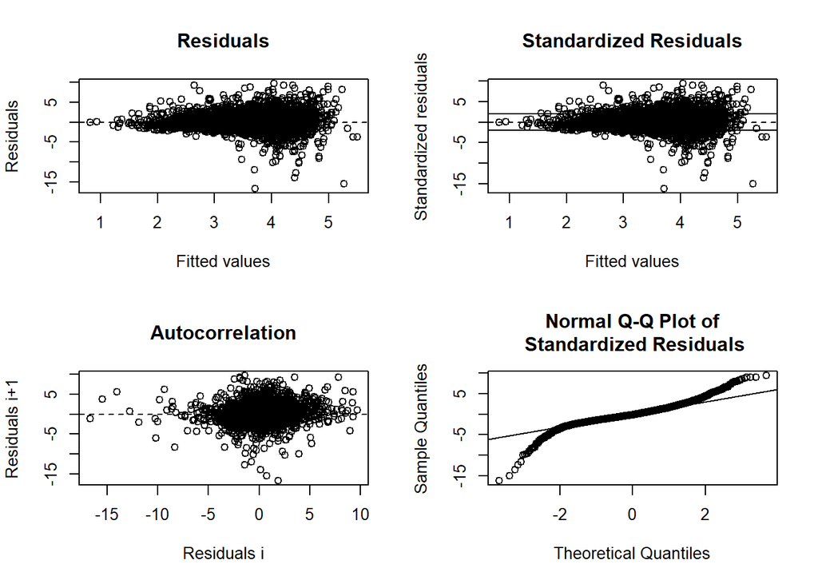

```
##
## ------
##  Shapiro-Wilk normality test
##
## data:  stdres
## W = 0.93745, p-value < 2.2e-16
##
##
## ------
```

```
##
##  Runs Test
##
## data:  as.factor(run)
## Standard Normal = -13.149, p-value < 2.2e-16
## alternative hypothesis: two.sided
```

## predict and plot

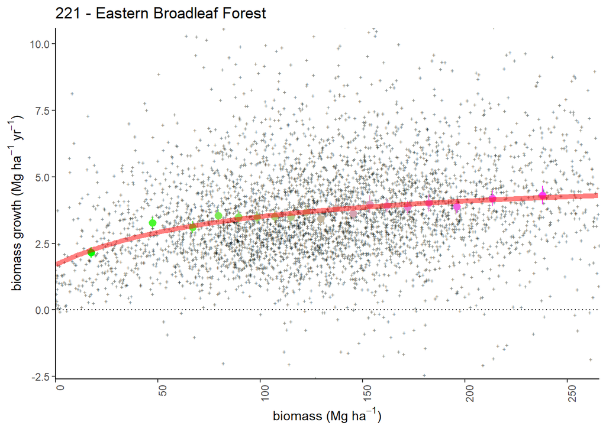

## plotting 2

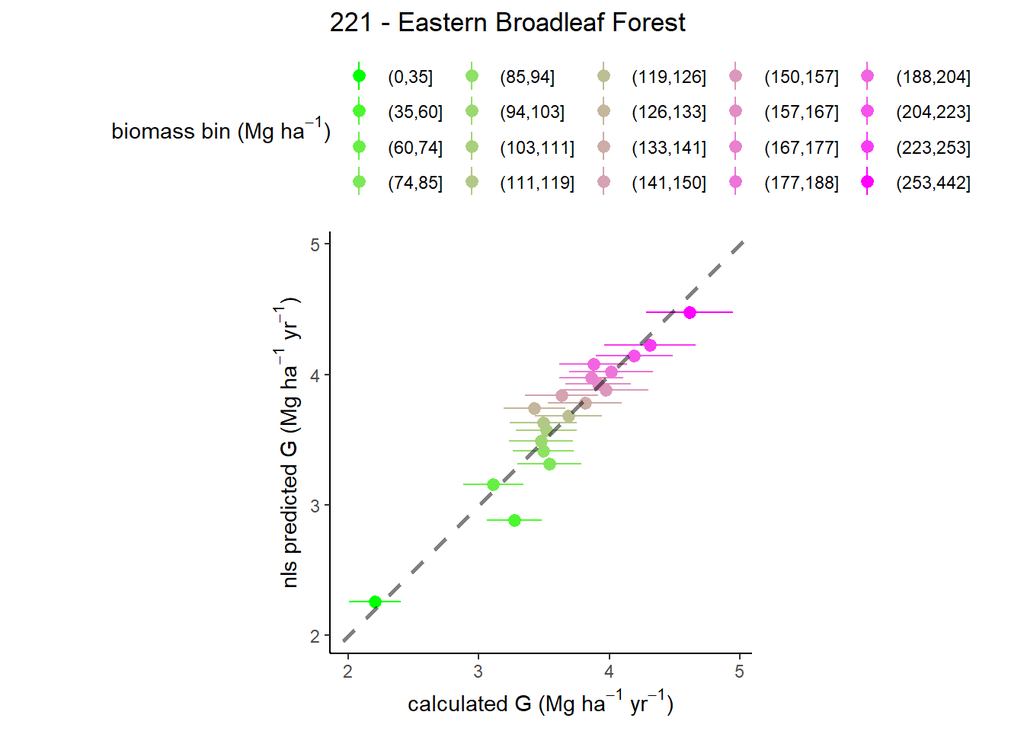

# 222 - Midwest Broadleaf Forest

## model selection 1

```
## Analysis of Variance Table
##
## Model 1: G_obs_TreeInc_MgHaYr ~ (1 + (MEASTIME_avg - 1990) * ge/100) * A * B_plt_t1_MgHa/(k + B_plt_t1_MgHa)
## Model 2: G_obs_TreeInc_MgHaYr ~ (1 + (MEASTIME_avg - 1990) * ge/100) * (1 + phi * DeltaPDSI) * A * B_plt_t1_MgHa/(k + B_plt_t1_MgHa)
## Model 3: G_obs_TreeInc_MgHaYr ~ (1 + (MEASTIME_avg - 1990) * ge/100) * (1 + phi * DeltaPDSI) * (1 - alpha * B_L_prop) * A * B_plt_t1_MgHa/(k + B_plt_t1_MgHa)
##   Res.Df Res.Sum Sq Df Sum Sq F value Pr(>F)
## 1   2570     2029.8
## 2   2569     2028.8  1  1.075  1.3613 0.2434
## 3   2568     1958.8  1 70.013 91.7896 <2e-16 ***
## ---
## Signif. codes:  0 '***' 0.001 '**' 0.01 '*' 0.05 '.' 0.1 ' ' 1
##   model      AIC
## 1     1 9403.476
## 2     2 9404.113
## 3     3 9315.750
```

```
##
## Formula: G_obs_TreeInc_MgHaYr ~ (1 + (MEASTIME_avg - 1990) * ge/100) *
##     (1 + phi * DeltaPDSI) * (1 - alpha * B_L_prop) * A * B_plt_t1_MgHa/(k +
##     B_plt_t1_MgHa)
##
## Parameters:
##       Estimate Std. Error t value Pr(>|t|)
## ge    -0.11677    0.24837  -0.470    0.638
## phi    0.01547    0.01034   1.497    0.135
## alpha  0.74932    0.07284  10.288   <2e-16 ***
## A      4.57812    0.22916  19.978   <2e-16 ***
## k     29.51696    2.43111  12.141   <2e-16 ***
## ---
## Signif. codes:  0 '***' 0.001 '**' 0.01 '*' 0.05 '.' 0.1 ' ' 1
##
## Residual standard error: 0.8734 on 2568 degrees of freedom
##
## Number of iterations to convergence: 6
## Achieved convergence tolerance: 9.669e-06
##   (3 observations deleted due to missingness)
```

### summary

- simple model: fits
- phi model: fits
- phi-alpha model: fits

## model selection 2

```
## Error in nls(get(paste("fg_", Mod.Sel1, "b", sep = "")), data = G_222,  :
##   number of iterations exceeded maximum of 50
## Error in nls(get(paste("fg_", Mod.Sel1, "c", sep = "")), data = G_222,  :
##   number of iterations exceeded maximum of 50
## Analysis of Variance Table
##
## Model 1: G_obs_TreeInc_MgHaYr ~ (1 + (MEASTIME_avg - 1990) * ge/100) * (1 + phi * DeltaPDSI) * (1 - alpha * B_L_prop) * A * B_plt_t1_MgHa/(k + B_plt_t1_MgHa)
## Model 2: G_obs_TreeInc_MgHaYr ~ (1 + (MEASTIME_avg - 1990) * ge/100) * (1 + phi * DeltaPDSI) * (1 - alpha * B_L_prop) * (p * A + ((1 - p) * A * B_plt_t1_MgHa/(k + B_plt_t1_MgHa)))
##   Res.Df Res.Sum Sq Df Sum Sq F value    Pr(>F)
## 1   2568     1958.8
## 2   2567     1919.3  1 39.459  52.775 4.938e-13 ***
## ---
## Signif. codes:  0 '***' 0.001 '**' 0.01 '*' 0.05 '.' 0.1 ' ' 1
##   model      AIC
## 1     3 9315.750
## 2    3a 9265.389
## 3    3b       NA
## 4    3c       NA
```

```
##
## Formula: G_obs_TreeInc_MgHaYr ~ (1 + (MEASTIME_avg - 1990) * ge/100) *
##     (1 + phi * DeltaPDSI) * (1 - alpha * B_L_prop) * (p * A +
##     ((1 - p) * A * B_plt_t1_MgHa/(k + B_plt_t1_MgHa)))
##
## Parameters:
##       Estimate Std. Error t value Pr(>|t|)
## ge    -0.16668    0.24120  -0.691    0.490
## phi    0.01320    0.01015   1.300    0.194
## alpha  0.72713    0.07200  10.099  < 2e-16 ***
## A      5.74650    0.39281  14.629  < 2e-16 ***
## k     86.09891   14.13553   6.091 1.29e-09 ***
## p      0.16849    0.01519  11.088  < 2e-16 ***
## ---
## Signif. codes:  0 '***' 0.001 '**' 0.01 '*' 0.05 '.' 0.1 ' ' 1
##
## Residual standard error: 0.8647 on 2567 degrees of freedom
##
## Number of iterations to convergence: 9
## Achieved convergence tolerance: 6.501e-06
##   (3 observations deleted due to missingness)
```

### summary

- add p model: fits
- add s model: does not fit
- add s+p model: does not fit

## plot residuals

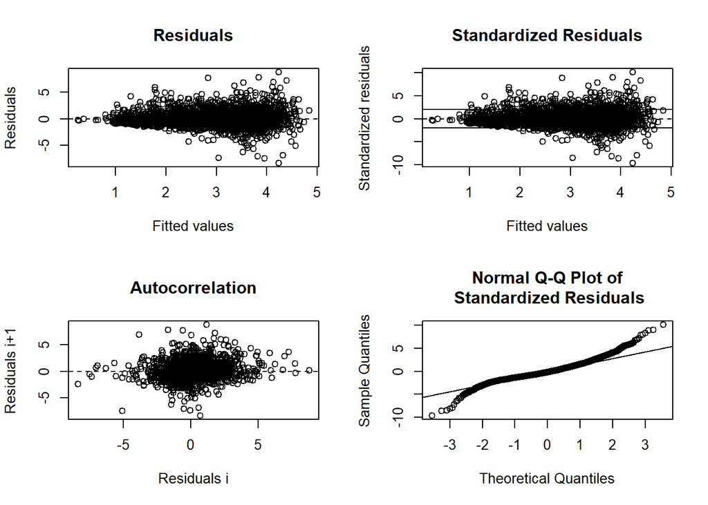

```
##
## ------
##  Shapiro-Wilk normality test
##
## data:  stdres
## W = 0.95129, p-value < 2.2e-16
##
##
## ------
```

```
##
##  Runs Test
##
## data:  as.factor(run)
## Standard Normal = -12.805, p-value < 2.2e-16
## alternative hypothesis: two.sided
```

## predict and plot

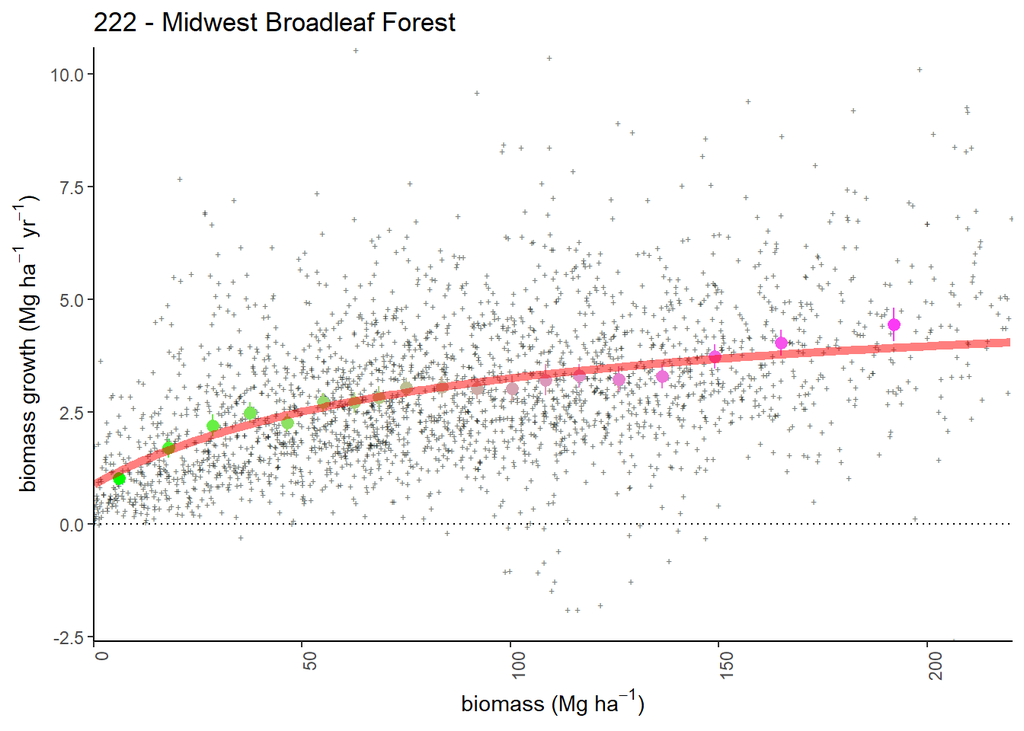

## plotting 2

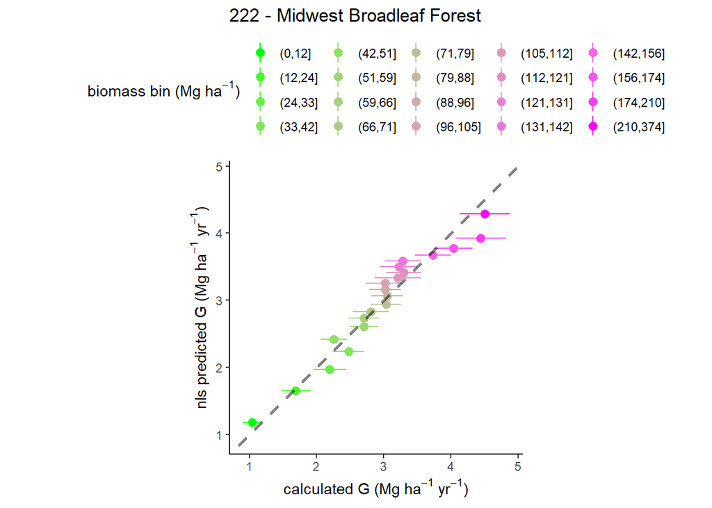

# 223 - Central Interior Broadleaf Forest

## model selection 1

```
## Analysis of Variance Table
##
## Model 1: G_obs_TreeInc_MgHaYr ~ (1 + (MEASTIME_avg - 1990) * ge/100) * A * B_plt_t1_MgHa/(k + B_plt_t1_MgHa)
## Model 2: G_obs_TreeInc_MgHaYr ~ (1 + (MEASTIME_avg - 1990) * ge/100) * (1 + phi * DeltaPDSI) * A * B_plt_t1_MgHa/(k + B_plt_t1_MgHa)
## Model 3: G_obs_TreeInc_MgHaYr ~ (1 + (MEASTIME_avg - 1990) * ge/100) * (1 + phi * DeltaPDSI) * (1 - alpha * B_L_prop) * A * B_plt_t1_MgHa/(k + B_plt_t1_MgHa)
##   Res.Df Res.Sum Sq Df Sum Sq F value    Pr(>F)
## 1   5019     4938.4
## 2   5018     4936.3  1  2.045  2.0789    0.1494
## 3   5017     4883.1  1 53.229 54.6892 1.646e-13 ***
## ---
## Signif. codes:  0 '***' 0.001 '**' 0.01 '*' 0.05 '.' 0.1 ' ' 1
##   model      AIC
## 1     1 19770.45
## 2     2 19770.37
## 3     3 19717.92
```

```
##
## Formula: G_obs_TreeInc_MgHaYr ~ (1 + (MEASTIME_avg - 1990) * ge/100) *
##     (1 + phi * DeltaPDSI) * (1 - alpha * B_L_prop) * A * B_plt_t1_MgHa/(k +
##     B_plt_t1_MgHa)
##
## Parameters:
##        Estimate Std. Error t value Pr(>|t|)
## ge    -1.395819   0.100403 -13.902  < 2e-16 ***
## phi   -0.010787   0.007786  -1.385    0.166
## alpha  0.605527   0.078781   7.686 1.81e-14 ***
## A      6.689444   0.248833  26.883  < 2e-16 ***
## k     46.537457   3.930067  11.841  < 2e-16 ***
## ---
## Signif. codes:  0 '***' 0.001 '**' 0.01 '*' 0.05 '.' 0.1 ' ' 1
##
## Residual standard error: 0.9866 on 5017 degrees of freedom
##
## Number of iterations to convergence: 8
## Achieved convergence tolerance: 6.123e-06
##   (2 observations deleted due to missingness)
```

### summary

- simple model: fits
- phi model: fits
- phi-alpha model: fits

## model selection 2

```
## Error in nls(get(paste("fg_", Mod.Sel1, "a", sep = "")), data = G_223,  :
##   number of iterations exceeded maximum of 50
## Error in nls(get(paste("fg_", Mod.Sel1, "b", sep = "")), data = G_223,  :
##   number of iterations exceeded maximum of 50
## Error in nls(get(paste("fg_", Mod.Sel1, "c", sep = "")), data = G_223,  :
##   step factor 0.000488281 reduced below 'minFactor' of 0.000976562
##   model      AIC
## 1     3 19717.92
## 2    3a       NA
## 3    3b       NA
## 4    3c       NA
```

```
##
## Formula: G_obs_TreeInc_MgHaYr ~ (1 + (MEASTIME_avg - 1990) * ge/100) *
##     (1 + phi * DeltaPDSI) * (1 - alpha * B_L_prop) * A * B_plt_t1_MgHa/(k +
##     B_plt_t1_MgHa)
##
## Parameters:
##        Estimate Std. Error t value Pr(>|t|)
## ge    -1.395819   0.100403 -13.902  < 2e-16 ***
## phi   -0.010787   0.007786  -1.385    0.166
## alpha  0.605527   0.078781   7.686 1.81e-14 ***
## A      6.689444   0.248833  26.883  < 2e-16 ***
## k     46.537457   3.930067  11.841  < 2e-16 ***
## ---
## Signif. codes:  0 '***' 0.001 '**' 0.01 '*' 0.05 '.' 0.1 ' ' 1
##
## Residual standard error: 0.9866 on 5017 degrees of freedom
##
## Number of iterations to convergence: 8
## Achieved convergence tolerance: 6.123e-06
##   (2 observations deleted due to missingness)
```

### summary

- add p model: does not fit
- add s model: does not fit
- add s+p model: does not fit

## plot residuals

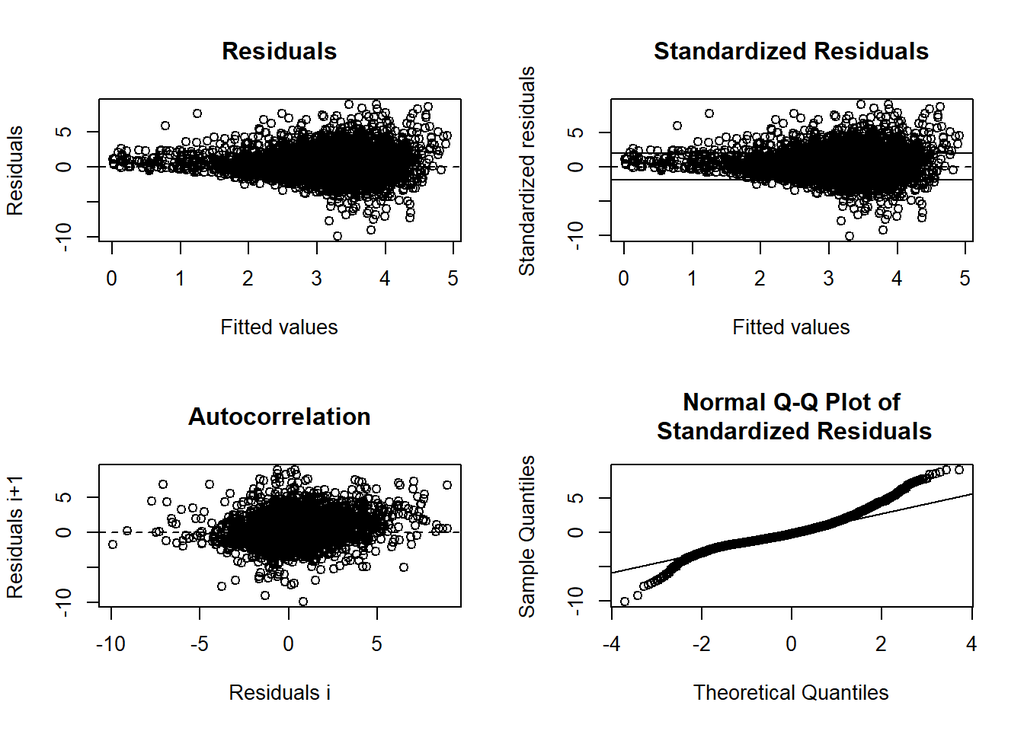

## predict and plot

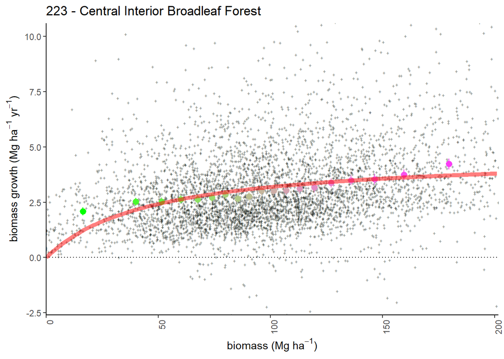

## plotting 2

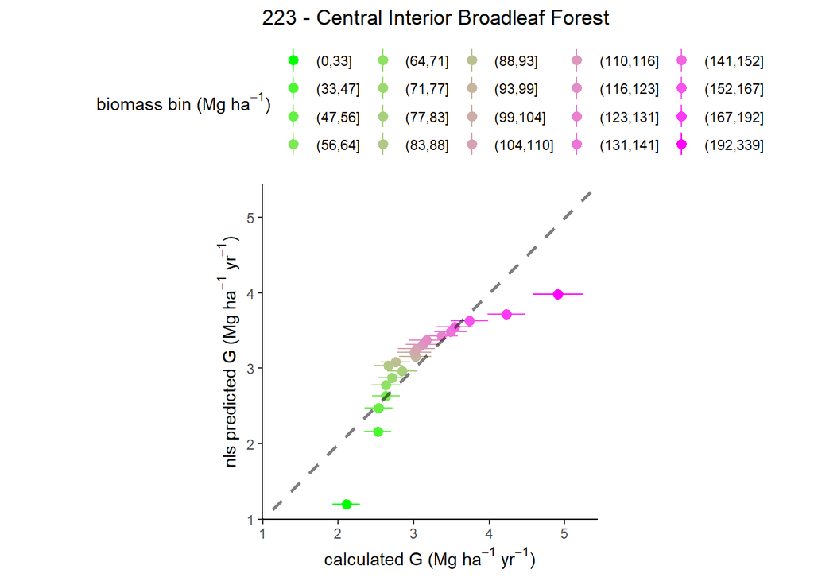

# 231 - Southeastern Mixed Forest

## model selection 1

```
## Analysis of Variance Table
##
## Model 1: G_obs_TreeInc_MgHaYr ~ (1 + (MEASTIME_avg - 1990) * ge/100) * A * B_plt_t1_MgHa/(k + B_plt_t1_MgHa)
## Model 2: G_obs_TreeInc_MgHaYr ~ (1 + (MEASTIME_avg - 1990) * ge/100) * (1 + phi * DeltaPDSI) * A * B_plt_t1_MgHa/(k + B_plt_t1_MgHa)
## Model 3: G_obs_TreeInc_MgHaYr ~ (1 + (MEASTIME_avg - 1990) * ge/100) * (1 + phi * DeltaPDSI) * (1 - alpha * B_L_prop) * A * B_plt_t1_MgHa/(k + B_plt_t1_MgHa)
##   Res.Df Res.Sum Sq Df  Sum Sq  F value Pr(>F)
## 1   5948     9775.4
## 2   5947     9772.9  1   2.496   1.5187 0.2179
## 3   5946     9560.4  1 212.460 132.1374 <2e-16 ***
## ---
## Signif. codes:  0 '***' 0.001 '**' 0.01 '*' 0.05 '.' 0.1 ' ' 1
##   model      AIC
## 1     1 29090.96
## 2     2 29091.44
## 3     3 28962.64
```

```
##
## Formula: G_obs_TreeInc_MgHaYr ~ (1 + (MEASTIME_avg - 1990) * ge/100) *
##     (1 + phi * DeltaPDSI) * (1 - alpha * B_L_prop) * A * B_plt_t1_MgHa/(k +
##     B_plt_t1_MgHa)
##
## Parameters:
##        Estimate Std. Error t value Pr(>|t|)
## ge    -0.382944   0.117872  -3.249  0.00117 **
## phi   -0.008115   0.005870  -1.382  0.16690
## alpha  0.830367   0.068575  12.109  < 2e-16 ***
## A      5.793137   0.155362  37.288  < 2e-16 ***
## k      3.741226   0.423068   8.843  < 2e-16 ***
## ---
## Signif. codes:  0 '***' 0.001 '**' 0.01 '*' 0.05 '.' 0.1 ' ' 1
##
## Residual standard error: 1.268 on 5946 degrees of freedom
##
## Number of iterations to convergence: 7
## Achieved convergence tolerance: 3.665e-06
##   (1 observation deleted due to missingness)
```

### summary

- simple model: fits
- phi model: fits
- phi-alpha model: fits

## model selection 2

```
## Analysis of Variance Table
##
## Model 1: G_obs_TreeInc_MgHaYr ~ (1 + (MEASTIME_avg - 1990) * ge/100) * (1 + phi * DeltaPDSI) * (1 - alpha * B_L_prop) * A * B_plt_t1_MgHa/(k + B_plt_t1_MgHa)
## Model 2: G_obs_TreeInc_MgHaYr ~ (1 + (MEASTIME_avg - 1990) * ge/100) * (1 + phi * DeltaPDSI) * (1 - alpha * B_L_prop) * (p * A + ((1 - p) * A * B_plt_t1_MgHa/(k + B_plt_t1_MgHa)))
## Model 3: G_obs_TreeInc_MgHaYr ~ (1 + (MEASTIME_avg - 1990) * ge/100) * (1 + phi * DeltaPDSI) * (1 - alpha * B_L_prop) * (A * B_plt_t1_MgHa^s/(k^s + B_plt_t1_MgHa^s))
## Model 4: G_obs_TreeInc_MgHaYr ~ (1 + (MEASTIME_avg - 1990) * ge/100) * (1 + phi * DeltaPDSI) * (1 - alpha * B_L_prop) * (p * A + ((1 - p) * A * B_plt_t1_MgHa^s/(k^s + B_plt_t1_MgHa^s)))
##   Res.Df Res.Sum Sq Df Sum Sq F value    Pr(>F)
## 1   5946     9560.4
## 2   5945     9525.5  1 34.904 21.7842 3.118e-06 ***
## 3   5945     9521.5  0  0.000
## 4   5944     9521.4  1  0.091  0.0569    0.8114
## ---
## Signif. codes:  0 '***' 0.001 '**' 0.01 '*' 0.05 '.' 0.1 ' ' 1
##   model      AIC
## 1     3 28962.64
## 2    3a 28942.87
## 3    3b 28940.38
## 4    3c 28942.32
```

```
##
## Formula: G_obs_TreeInc_MgHaYr ~ (1 + (MEASTIME_avg - 1990) * ge/100) *
##     (1 + phi * DeltaPDSI) * (1 - alpha * B_L_prop) * (A * B_plt_t1_MgHa^s/(k^s +
##     B_plt_t1_MgHa^s))
##
## Parameters:
##        Estimate Std. Error t value Pr(>|t|)
## ge    -0.427258   0.115813  -3.689 0.000227 ***
## phi   -0.007954   0.005848  -1.360 0.173887
## alpha  0.818471   0.068182  12.004  < 2e-16 ***
## A      6.754254   0.458619  14.727  < 2e-16 ***
## k      3.896714   1.015392   3.838 0.000126 ***
## s      0.491849   0.087099   5.647 1.71e-08 ***
## ---
## Signif. codes:  0 '***' 0.001 '**' 0.01 '*' 0.05 '.' 0.1 ' ' 1
##
## Residual standard error: 1.266 on 5945 degrees of freedom
##
## Number of iterations to convergence: 5
## Achieved convergence tolerance: 8.897e-07
##   (1 observation deleted due to missingness)
```

### summary

- add p model: fits
- add s model: fits
- add s+p model: fits

## plot residuals

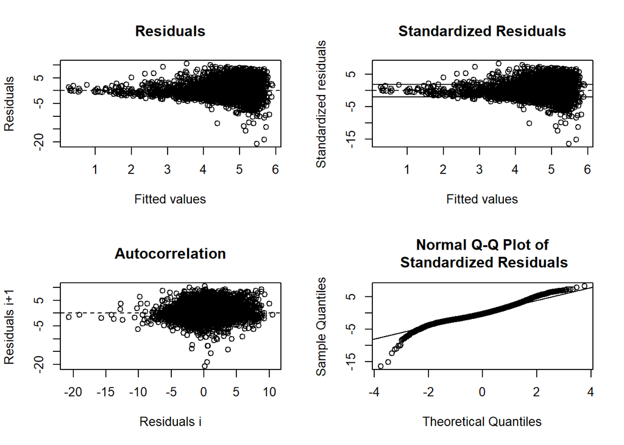

## predict and plot

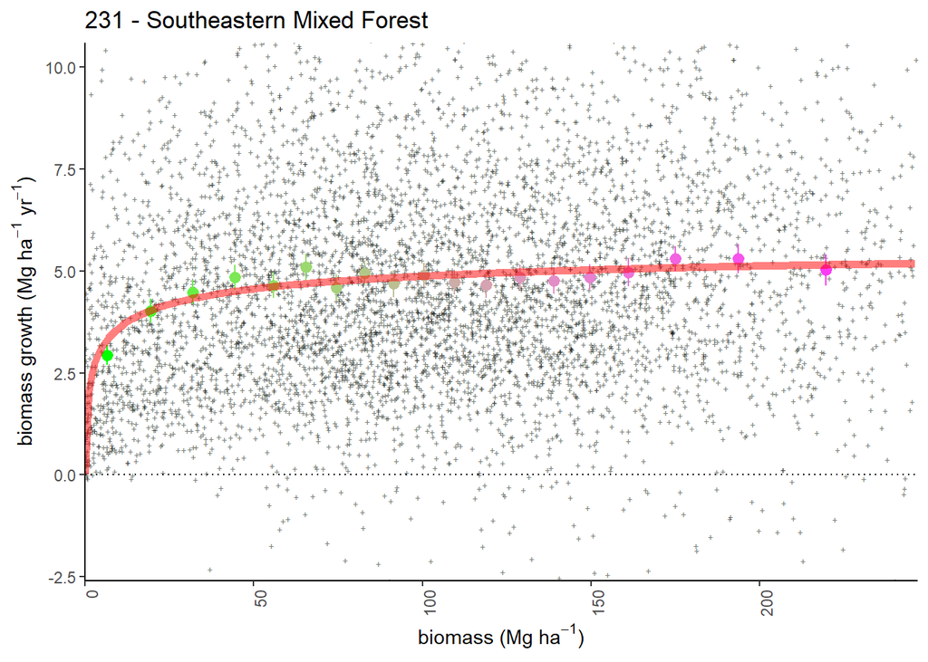

## plotting 2

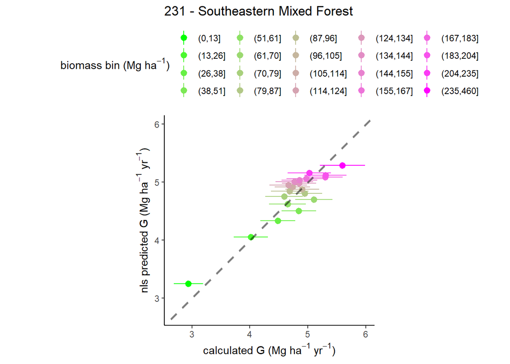

# 232 - Outer Coastal Plain Mixed Forest

## model selection 1

```
## Analysis of Variance Table
##
## Model 1: G_obs_TreeInc_MgHaYr ~ (1 + (MEASTIME_avg - 1990) * ge/100) * A * B_plt_t1_MgHa/(k + B_plt_t1_MgHa)
## Model 2: G_obs_TreeInc_MgHaYr ~ (1 + (MEASTIME_avg - 1990) * ge/100) * (1 + phi * DeltaPDSI) * A * B_plt_t1_MgHa/(k + B_plt_t1_MgHa)
## Model 3: G_obs_TreeInc_MgHaYr ~ (1 + (MEASTIME_avg - 1990) * ge/100) * (1 + phi * DeltaPDSI) * (1 - alpha * B_L_prop) * A * B_plt_t1_MgHa/(k + B_plt_t1_MgHa)
##   Res.Df Res.Sum Sq Df  Sum Sq  F value Pr(>F)
## 1   6116      12530
## 2   6115      12525  1   5.459   2.6652 0.1026
## 3   6114      12243  1 282.145 140.9047 <2e-16 ***
## ---
## Signif. codes:  0 '***' 0.001 '**' 0.01 '*' 0.05 '.' 0.1 ' ' 1
##   model      AIC
## 1     1 30256.20
## 2     2 30255.53
## 3     3 30118.11
```

```
##
## Formula: G_obs_TreeInc_MgHaYr ~ (1 + (MEASTIME_avg - 1990) * ge/100) *
##     (1 + phi * DeltaPDSI) * (1 - alpha * B_L_prop) * A * B_plt_t1_MgHa/(k +
##     B_plt_t1_MgHa)
##
## Parameters:
##       Estimate Std. Error t value Pr(>|t|)
## ge    -0.31636    0.14792  -2.139   0.0325 *
## phi   -0.01430    0.00642  -2.227   0.0260 *
## alpha  0.79920    0.06330  12.627   <2e-16 ***
## A      5.62682    0.19520  28.826   <2e-16 ***
## k     11.25389    0.89831  12.528   <2e-16 ***
## ---
## Signif. codes:  0 '***' 0.001 '**' 0.01 '*' 0.05 '.' 0.1 ' ' 1
##
## Residual standard error: 1.415 on 6114 degrees of freedom
##
## Number of iterations to convergence: 6
## Achieved convergence tolerance: 3.095e-06
##   (1 observation deleted due to missingness)
```

### summary

- simple model: fits
- phi model: fits
- phi-alpha model: fits

## model selection 2

```
## Analysis of Variance Table
##
## Model 1: G_obs_TreeInc_MgHaYr ~ (1 + (MEASTIME_avg - 1990) * ge/100) * (1 + phi * DeltaPDSI) * (1 - alpha * B_L_prop) * A * B_plt_t1_MgHa/(k + B_plt_t1_MgHa)
## Model 2: G_obs_TreeInc_MgHaYr ~ (1 + (MEASTIME_avg - 1990) * ge/100) * (1 + phi * DeltaPDSI) * (1 - alpha * B_L_prop) * (p * A + ((1 - p) * A * B_plt_t1_MgHa/(k + B_plt_t1_MgHa)))
## Model 3: G_obs_TreeInc_MgHaYr ~ (1 + (MEASTIME_avg - 1990) * ge/100) * (1 + phi * DeltaPDSI) * (1 - alpha * B_L_prop) * (A * B_plt_t1_MgHa^s/(k^s + B_plt_t1_MgHa^s))
## Model 4: G_obs_TreeInc_MgHaYr ~ (1 + (MEASTIME_avg - 1990) * ge/100) * (1 + phi * DeltaPDSI) * (1 - alpha * B_L_prop) * (p * A + ((1 - p) * A * B_plt_t1_MgHa^s/(k^s + B_plt_t1_MgHa^s)))
##   Res.Df Res.Sum Sq Df  Sum Sq F value    Pr(>F)
## 1   6114      12243
## 2   6113      12114  1 128.959  65.078 8.598e-16 ***
## 3   6113      12139  0   0.000
## 4   6112      12113  1  26.284  13.263  0.000273 ***
## ---
## Signif. codes:  0 '***' 0.001 '**' 0.01 '*' 0.05 '.' 0.1 ' ' 1
##   model      AIC
## 1     3 30118.11
## 2    3a 30055.31
## 3    3b 30068.06
## 4    3c 30056.79
```

```
##
## Formula: G_obs_TreeInc_MgHaYr ~ (1 + (MEASTIME_avg - 1990) * ge/100) *
##     (1 + phi * DeltaPDSI) * (1 - alpha * B_L_prop) * (p * A +
##     ((1 - p) * A * B_plt_t1_MgHa/(k + B_plt_t1_MgHa)))
##
## Parameters:
##        Estimate Std. Error t value Pr(>|t|)
## ge    -0.335117   0.145689  -2.300   0.0215 *
## phi   -0.014823   0.006365  -2.329   0.0199 *
## alpha  0.773800   0.062414  12.398  < 2e-16 ***
## A      6.120930   0.241923  25.301  < 2e-16 ***
## k     31.226419   4.981374   6.269 3.89e-10 ***
## p      0.270663   0.025830  10.479  < 2e-16 ***
## ---
## Signif. codes:  0 '***' 0.001 '**' 0.01 '*' 0.05 '.' 0.1 ' ' 1
##
## Residual standard error: 1.408 on 6113 degrees of freedom
##
## Number of iterations to convergence: 5
## Achieved convergence tolerance: 2.32e-06
##   (1 observation deleted due to missingness)
```

### summary

- add p model: fits
- add s model: fits
- add s+p model: fits

## plot residuals

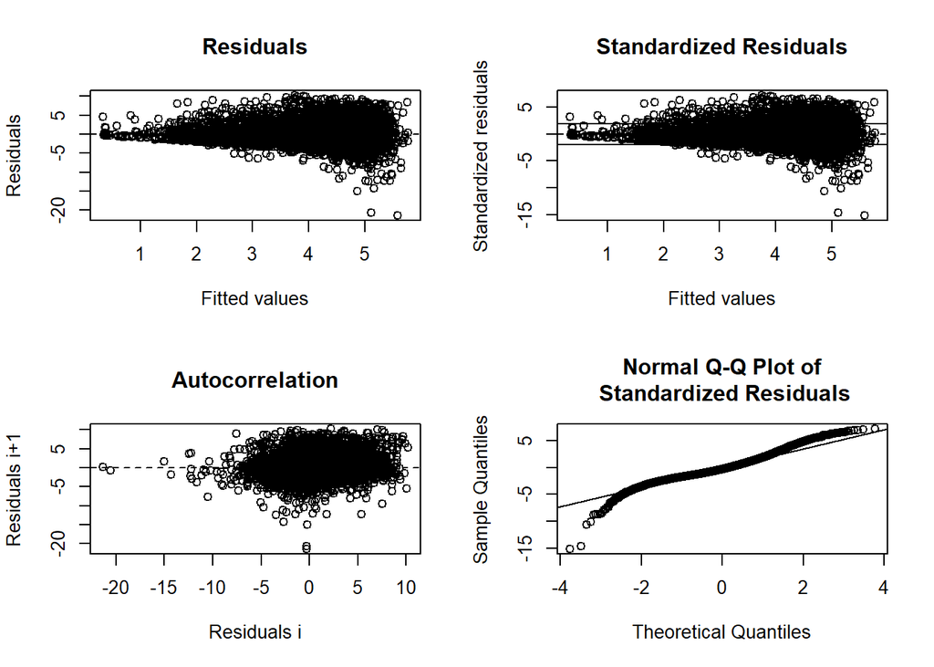

## predict and plot

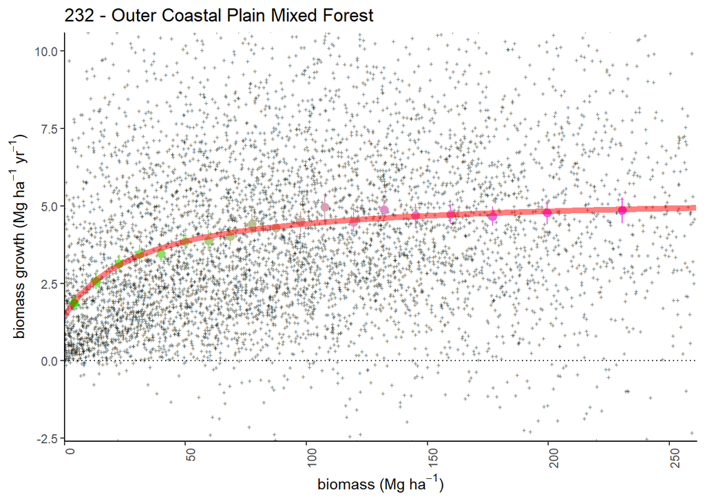

## plotting 2

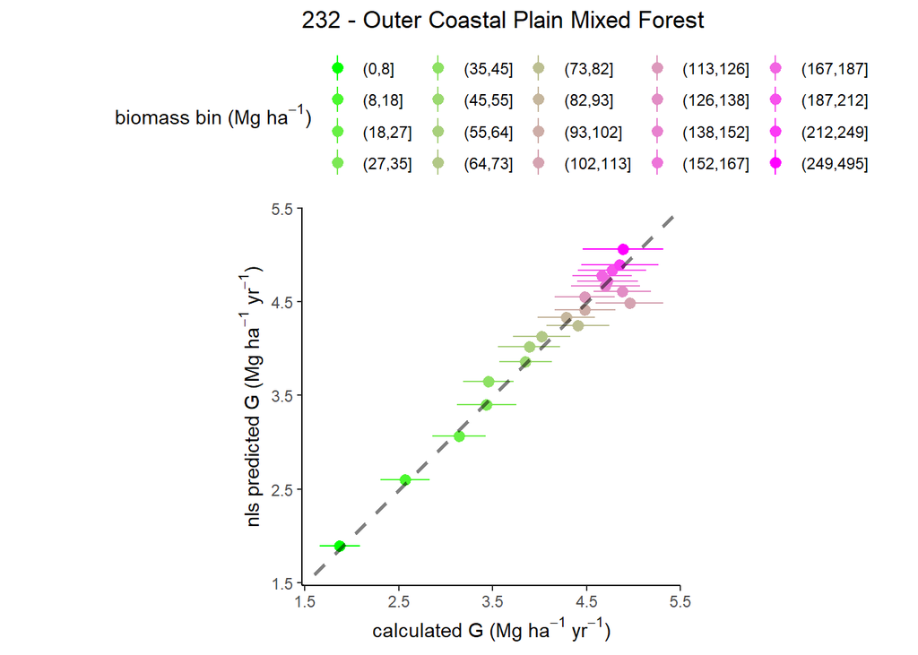

# 234 - Lower Mississippi Riverine Forest

## model selection 1

```
## Analysis of Variance Table
##
## Model 1: G_obs_TreeInc_MgHaYr ~ (1 + (MEASTIME_avg - 1990) * ge/100) * A * B_plt_t1_MgHa/(k + B_plt_t1_MgHa)
## Model 2: G_obs_TreeInc_MgHaYr ~ (1 + (MEASTIME_avg - 1990) * ge/100) * (1 + phi * DeltaPDSI) * A * B_plt_t1_MgHa/(k + B_plt_t1_MgHa)
## Model 3: G_obs_TreeInc_MgHaYr ~ (1 + (MEASTIME_avg - 1990) * ge/100) * (1 + phi * DeltaPDSI) * (1 - alpha * B_L_prop) * A * B_plt_t1_MgHa/(k + B_plt_t1_MgHa)
##   Res.Df Res.Sum Sq Df Sum Sq F value    Pr(>F)
## 1    636     1338.6
## 2    635     1338.6  1  0.012  0.0059    0.9387
## 3    634     1294.5  1 44.064 21.5813 4.126e-06 ***
## ---
## Signif. codes:  0 '***' 0.001 '**' 0.01 '*' 0.05 '.' 0.1 ' ' 1
##   model      AIC
## 1     1 3155.120
## 2     2 3157.114
## 3     3 3137.724
```

```
##
## Formula: G_obs_TreeInc_MgHaYr ~ (1 + (MEASTIME_avg - 1990) * ge/100) *
##     (1 + phi * DeltaPDSI) * (1 - alpha * B_L_prop) * A * B_plt_t1_MgHa/(k +
##     B_plt_t1_MgHa)
##
## Parameters:
##         Estimate Std. Error t value Pr(>|t|)
## ge     0.0232856  0.7867843   0.030  0.97640
## phi   -0.0004531  0.0290243  -0.016  0.98755
## alpha  0.8796222  0.1747124   5.035 6.25e-07 ***
## A      4.9486376  0.8241030   6.005 3.23e-09 ***
## k     14.0418545  4.5397219   3.093  0.00207 **
## ---
## Signif. codes:  0 '***' 0.001 '**' 0.01 '*' 0.05 '.' 0.1 ' ' 1
##
## Residual standard error: 1.429 on 634 degrees of freedom
##
## Number of iterations to convergence: 5
## Achieved convergence tolerance: 7.934e-06
##   (1 observation deleted due to missingness)
```

### summary

- simple model: fits
- phi model: fits
- phi-alpha model: fits

## model selection 2

```
## Error in nls(get(paste("fg_", Mod.Sel1, "c", sep = "")), data = G_234,  :
##   parameters without starting value in 'data': p
## Analysis of Variance Table
##
## Model 1: G_obs_TreeInc_MgHaYr ~ (1 + (MEASTIME_avg - 1990) * ge/100) * (1 + phi * DeltaPDSI) * (1 - alpha * B_L_prop) * A * B_plt_t1_MgHa/(k + B_plt_t1_MgHa)
## Model 2: G_obs_TreeInc_MgHaYr ~ (1 + (MEASTIME_avg - 1990) * ge/100) * (1 + phi * DeltaPDSI) * (1 - alpha * B_L_prop) * (p * A + ((1 - p) * A * B_plt_t1_MgHa/(k + B_plt_t1_MgHa)))
##   Res.Df Res.Sum Sq Df Sum Sq F value Pr(>F)
## 1    634     1294.5
## 2    633     1291.1  1 3.4067  1.6702 0.1967
##   model      AIC
## 1     3 3137.724
## 2    3a 3138.040
## 3    3b 3139.199
## 4    3c       NA
```

```
##
## Formula: G_obs_TreeInc_MgHaYr ~ (1 + (MEASTIME_avg - 1990) * ge/100) *
##     (1 + phi * DeltaPDSI) * (1 - alpha * B_L_prop) * A * B_plt_t1_MgHa/(k +
##     B_plt_t1_MgHa)
##
## Parameters:
##         Estimate Std. Error t value Pr(>|t|)
## ge     0.0232856  0.7867843   0.030  0.97640
## phi   -0.0004531  0.0290243  -0.016  0.98755
## alpha  0.8796222  0.1747124   5.035 6.25e-07 ***
## A      4.9486376  0.8241030   6.005 3.23e-09 ***
## k     14.0418545  4.5397219   3.093  0.00207 **
## ---
## Signif. codes:  0 '***' 0.001 '**' 0.01 '*' 0.05 '.' 0.1 ' ' 1
##
## Residual standard error: 1.429 on 634 degrees of freedom
##
## Number of iterations to convergence: 5
## Achieved convergence tolerance: 7.934e-06
##   (1 observation deleted due to missingness)
```

### summary

- add p model: fits
- add s model: fits
- add s+p model: does not fit

## plot residuals

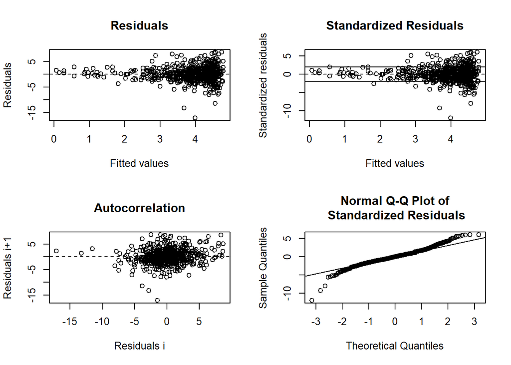

```
##
## ------
##  Shapiro-Wilk normality test
##
## data:  stdres
## W = 0.96254, p-value = 1.073e-11
##
##
## ------
```

```
##
##  Runs Test
##
## data:  as.factor(run)
## Standard Normal = -3.9043, p-value = 9.449e-05
## alternative hypothesis: two.sided
```

## predict and plot

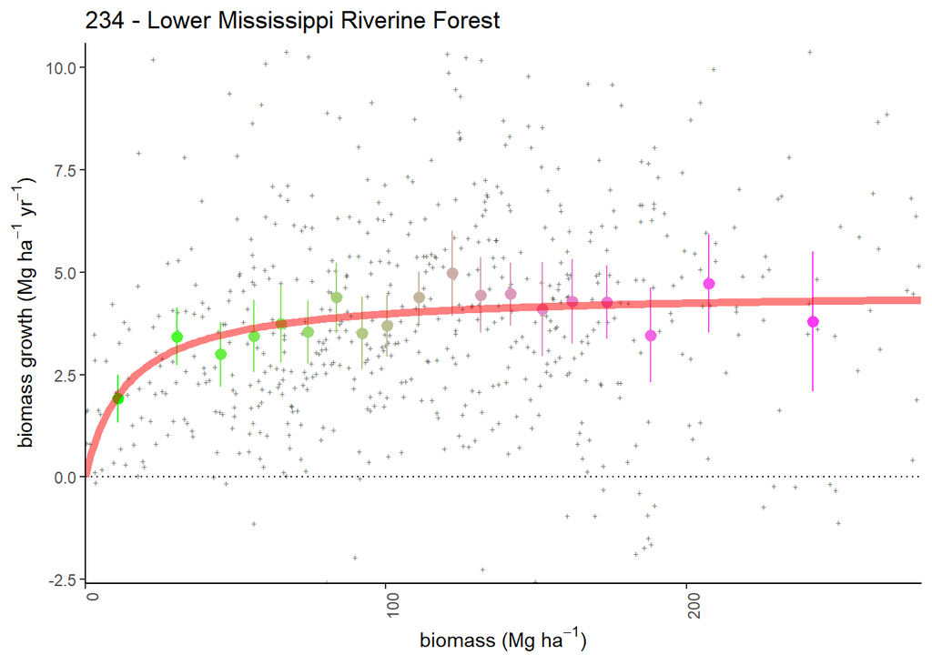

## plotting 2

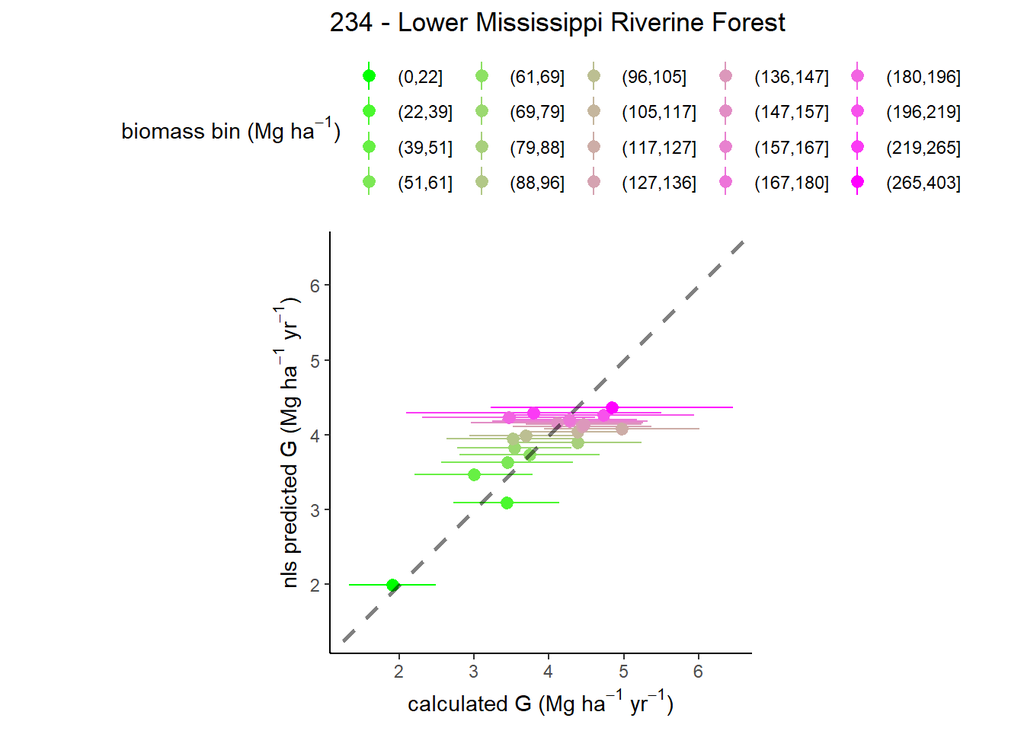

# 242 - Pacific Lowland Mixed Forest

## model selection 1

```
## Error in if (any(nEQ <- vNms != make.names(vNms))) vNms[nEQ] <- paste0("`",  :
##   missing value where TRUE/FALSE needed
## Error in if (any(nEQ <- vNms != make.names(vNms))) vNms[nEQ] <- paste0("`",  :
##   missing value where TRUE/FALSE needed
## Error in if (any(nEQ <- vNms != make.names(vNms))) vNms[nEQ] <- paste0("`",  :
##   missing value where TRUE/FALSE needed
##   model AIC
## 1     1  NA
## 2     2  NA
## 3     3  NA
```

[output not shown]

### summary

- simple model: does not fit
- phi model: does not fit
- phi-alpha model: does not fit

## model selection 2

### summary

- add p model: does not fit
- add s model: does not fit
- add s+p model: does not fit

## plot residuals

```
## [1] "cannot plot residuals"
```

## predict and plot

```
## [1] "cannot plot data with prediction"
```

## plotting 2

# 251 - Prairie Parkland (Temperate)

## model selection 1

```
## Analysis of Variance Table
##
## Model 1: G_obs_TreeInc_MgHaYr ~ (1 + (MEASTIME_avg - 1990) * ge/100) * A * B_plt_t1_MgHa/(k + B_plt_t1_MgHa)
## Model 2: G_obs_TreeInc_MgHaYr ~ (1 + (MEASTIME_avg - 1990) * ge/100) * (1 + phi * DeltaPDSI) * A * B_plt_t1_MgHa/(k + B_plt_t1_MgHa)
## Model 3: G_obs_TreeInc_MgHaYr ~ (1 + (MEASTIME_avg - 1990) * ge/100) * (1 + phi * DeltaPDSI) * (1 - alpha * B_L_prop) * A * B_plt_t1_MgHa/(k + B_plt_t1_MgHa)
##   Res.Df Res.Sum Sq Df Sum Sq F value  Pr(>F)
## 1   1108     908.57
## 2   1107     907.29  1 1.2829  1.5653 0.21115
## 3   1106     903.35  1 3.9411  4.8253 0.02825 *
## ---
## Signif. codes:  0 '***' 0.001 '**' 0.01 '*' 0.05 '.' 0.1 ' ' 1
##   model      AIC
## 1     1 4016.176
## 2     2 4016.606
## 3     3 4013.769
```

```
##
## Formula: G_obs_TreeInc_MgHaYr ~ (1 + (MEASTIME_avg - 1990) * ge/100) *
##     (1 + phi * DeltaPDSI) * (1 - alpha * B_L_prop) * A * B_plt_t1_MgHa/(k +
##     B_plt_t1_MgHa)
##
## Parameters:
##       Estimate Std. Error t value Pr(>|t|)
## ge    -0.81303    0.30440  -2.671  0.00768 **
## phi    0.01479    0.01346   1.099  0.27204
## alpha  0.30954    0.13674   2.264  0.02379 *
## A      4.17197    0.32580  12.805  < 2e-16 ***
## k     22.19269    3.95312   5.614  2.5e-08 ***
## ---
## Signif. codes:  0 '***' 0.001 '**' 0.01 '*' 0.05 '.' 0.1 ' ' 1
##
## Residual standard error: 0.9038 on 1106 degrees of freedom
##
## Number of iterations to convergence: 7
## Achieved convergence tolerance: 5.148e-06
##   (1 observation deleted due to missingness)
```

### summary

- simple model: fits
- phi model: fits
- phi-alpha model: fits

## model selection 2

```
## Error in nls(get(paste("fg_", Mod.Sel1, "b", sep = "")), data = G_251,  :
##   step factor 0.000488281 reduced below 'minFactor' of 0.000976562
## Analysis of Variance Table
##
## Model 1: G_obs_TreeInc_MgHaYr ~ (1 + (MEASTIME_avg - 1990) * ge/100) * (1 + phi * DeltaPDSI) * (1 - alpha * B_L_prop) * A * B_plt_t1_MgHa/(k + B_plt_t1_MgHa)
## Model 2: G_obs_TreeInc_MgHaYr ~ (1 + (MEASTIME_avg - 1990) * ge/100) * (1 + phi * DeltaPDSI) * (1 - alpha * B_L_prop) * (p * A + ((1 - p) * A * B_plt_t1_MgHa/(k + B_plt_t1_MgHa)))
## Model 3: G_obs_TreeInc_MgHaYr ~ (1 + (MEASTIME_avg - 1990) * ge/100) * (1 + phi * DeltaPDSI) * (1 - alpha * B_L_prop) * (p * A + ((1 - p) * A * B_plt_t1_MgHa^s/(k^s + B_plt_t1_MgHa^s)))
##   Res.Df Res.Sum Sq Df Sum Sq F value    Pr(>F)
## 1   1106     903.35
## 2   1105     869.87  1 33.478 42.5278 1.058e-10 ***
## 3   1104     867.93  1  1.943  2.4712    0.1162
## ---
## Signif. codes:  0 '***' 0.001 '**' 0.01 '*' 0.05 '.' 0.1 ' ' 1
##   model      AIC
## 1     3 4013.769
## 2    3a 3973.813
## 3    3b       NA
## 4    3c 3973.329
```

```
##
## Formula: G_obs_TreeInc_MgHaYr ~ (1 + (MEASTIME_avg - 1990) * ge/100) *
##     (1 + phi * DeltaPDSI) * (1 - alpha * B_L_prop) * (p * A +
##     ((1 - p) * A * B_plt_t1_MgHa^s/(k^s + B_plt_t1_MgHa^s)))
##
## Parameters:
##        Estimate Std. Error t value Pr(>|t|)
## ge     -0.86779    0.29008  -2.992 0.002837 **
## phi     0.01514    0.01319   1.147 0.251569
## alpha   0.30048    0.13388   2.244 0.025006 *
## A       5.10875    1.38709   3.683 0.000242 ***
## k     133.15468   60.68992   2.194 0.028442 *
## s       2.19950    1.12865   1.949 0.051574 .
## p       0.47930    0.15010   3.193 0.001447 **
## ---
## Signif. codes:  0 '***' 0.001 '**' 0.01 '*' 0.05 '.' 0.1 ' ' 1
##
## Residual standard error: 0.8867 on 1104 degrees of freedom
##
## Number of iterations to convergence: 19
## Achieved convergence tolerance: 2.56e-06
##   (1 observation deleted due to missingness)
```

### summary

- add p model: fits
- add s model: does not fit
- add s+p model: fits

## plot residuals

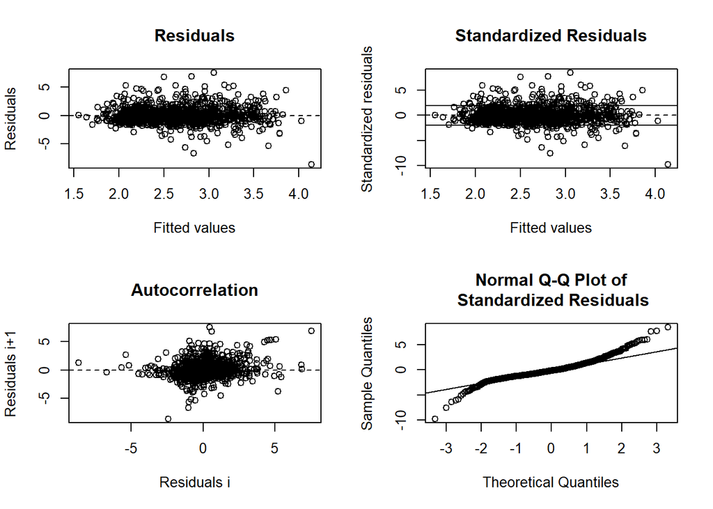

```
##
## ------
##  Shapiro-Wilk normality test
##
## data:  stdres
## W = 0.93443, p-value < 2.2e-16
##
##
## ------
```

```
##
##  Runs Test
##
## data:  as.factor(run)
## Standard Normal = -5.4717, p-value = 4.457e-08
## alternative hypothesis: two.sided
```

## predict and plot

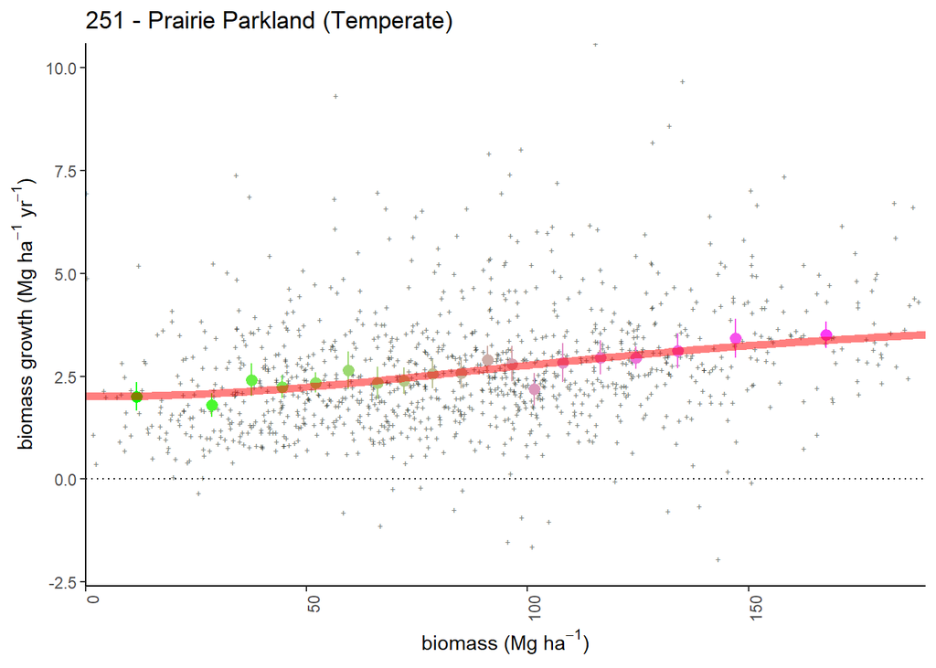

## plotting 2

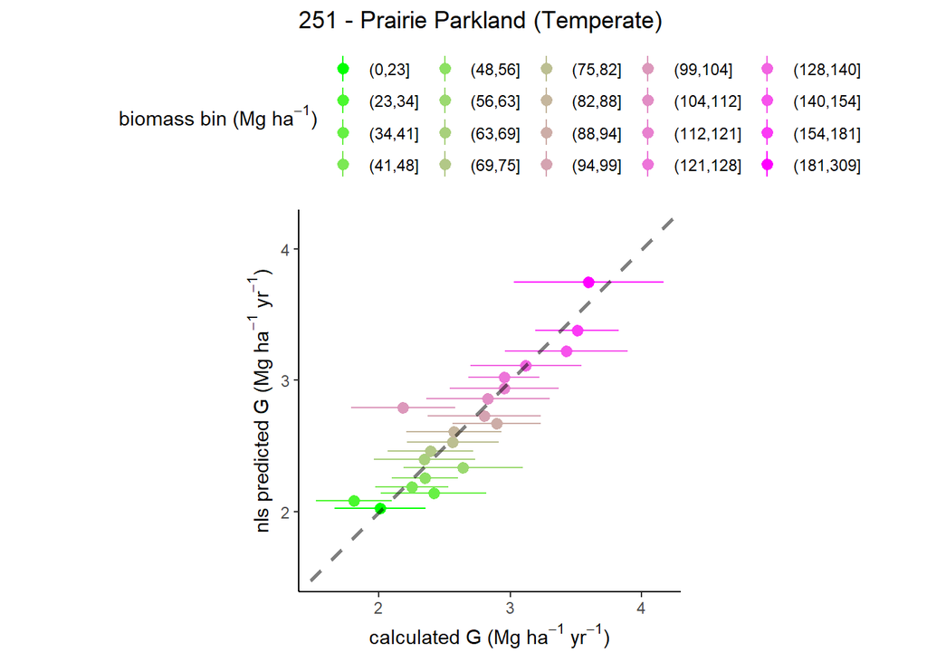

# 255 - Prairie Parkland (Subtropical)

## model selection 1

```
## Error in nls(fg_1, data = G_255, start = c(ge = ge.start, A = A.start,  :
##   number of iterations exceeded maximum of 50
## Error in nls(fg_2, data = G_255, start = c(ge = ge.start, phi = phi.start,  :
##   number of iterations exceeded maximum of 50
## Error in nls(fg_3, data = G_255, start = c(ge = ge.start, phi = phi.start,  :
##   number of iterations exceeded maximum of 50
##   model AIC
## 1     1  NA
## 2     2  NA
## 3     3  NA
```

[output not shown]

### summary

- simple model: does not fit
- phi model: does not fit
- phi-alpha model: does not fit

## model selection 2

### summary

- add p model: does not fit
- add s model: does not fit
- add s+p model: does not fit

## plot residuals

```
## [1] "cannot plot residuals"
```

## predict and plot

```
## [1] "cannot plot data with prediction"
```

## plotting 2

# 261 - California Coastal Chaparral Forest and Shrub

## model selection 1

### summary

- simple model: does not fit
- phi model: does not fit
- phi-alpha model: does not fit

## model selection 2

### summary

- add p model: does not fit
- add s model: does not fit
- add s+p model: does not fit

## plot residuals

```
## [1] "cannot plot residuals"
```

## predict and plot

```
## [1] "cannot plot data with prediction"
```

## plotting 2

# 262 - California Dry Steppe

## model selection 1

### summary

- simple model: does not fit
- phi model: does not fit
- phi-alpha model: does not fit

## model selection 2

### summary

- add p model: does not fit
- add s model: does not fit
- add s+p model: does not fit

## plot residuals

```
## [1] "cannot plot residuals"
```

## predict and plot

```
## [1] "cannot plot data with prediction"
```

## plotting 2

# 263 - California Coastal Steppe - Mixed Forest and Redwood Forest

## model selection 1

```
## Error in if (any(nEQ <- vNms != make.names(vNms))) vNms[nEQ] <- paste0("`",  :
##   missing value where TRUE/FALSE needed
## Error in if (any(nEQ <- vNms != make.names(vNms))) vNms[nEQ] <- paste0("`",  :
##   missing value where TRUE/FALSE needed
## Error in if (any(nEQ <- vNms != make.names(vNms))) vNms[nEQ] <- paste0("`",  :
##   missing value where TRUE/FALSE needed
##   model AIC
## 1     1  NA
## 2     2  NA
## 3     3  NA
```

[output not shown]

### summary

- simple model: does not fit
- phi model: does not fit
- phi-alpha model: does not fit

## model selection 2

### summary

- add p model: does not fit
- add s model: does not fit
- add s+p model: does not fit

## plot residuals

```
## [1] "cannot plot residuals"
```

## predict and plot

```
## [1] "cannot plot data with prediction"
```

## plotting 2

# 313 - Colorado Plateau Semi-Desert

## model selection 1

```
## Error in if (any(nEQ <- vNms != make.names(vNms))) vNms[nEQ] <- paste0("`",  :
##   missing value where TRUE/FALSE needed
## Error in if (any(nEQ <- vNms != make.names(vNms))) vNms[nEQ] <- paste0("`",  :
##   missing value where TRUE/FALSE needed
## Error in if (any(nEQ <- vNms != make.names(vNms))) vNms[nEQ] <- paste0("`",  :
##   missing value where TRUE/FALSE needed
##   model AIC
## 1     1  NA
## 2     2  NA
## 3     3  NA
```

[output not shown]

### summary

- simple model: does not fit
- phi model: does not fit
- phi-alpha model: does not fit

## model selection 2

### summary

- add p model: does not fit
- add s model: does not fit
- add s+p model: does not fit

## plot residuals

```
## [1] "cannot plot residuals"
```

## predict and plot

```
## [1] "cannot plot data with prediction"
```

## plotting 2

# 315 - Southwest Plateau and Plains Dry Steppe and Shrub

## model selection 1

### summary

- simple model: does not fit
- phi model: does not fit
- phi-alpha model: does not fit

## model selection 2

### summary

- add p model: does not fit
- add s model: does not fit
- add s+p model: does not fit

## plot residuals

```
## [1] "cannot plot residuals"
```

## predict and plot

```
## [1] "cannot plot data with prediction"
```

## plotting 2

# 321 - Chihuahuan Semi-Desert

## model selection 1

### summary

- simple model: does not fit
- phi model: does not fit
- phi-alpha model: does not fit

## model selection 2

### summary

- add p model: does not fit
- add s model: does not fit
- add s+p model: does not fit

## plot residuals

```
## [1] "cannot plot residuals"
```

## predict and plot

```
## [1] "cannot plot data with prediction"
```

## plotting 2

# 322 - American Semidesert and Desert

## model selection 1

### summary

- simple model: does not fit
- phi model: does not fit
- phi-alpha model: does not fit

## model selection 2

### summary

- add p model: does not fit
- add s model: does not fit
- add s+p model: does not fit

## plot residuals

```
## [1] "cannot plot residuals"
```

## predict and plot

```
## [1] "cannot plot data with prediction"
```

## plotting 2

# 331 - Great Plains/Palouse Dry Steppe

## model selection 1

```
## Error in nls(fg_1, data = G_331, start = c(ge = ge.start, A = A.start,  :
##   missing or negative weights not allowed
## Error in nls(fg_2, data = G_331, start = c(ge = ge.start, phi = phi.start,  :
##   missing or negative weights not allowed
## Error in nls(fg_3, data = G_331, start = c(ge = ge.start, phi = phi.start,  :
##   missing or negative weights not allowed
##   model AIC
## 1     1  NA
## 2     2  NA
## 3     3  NA
```

[output not shown]

### summary

- simple model: does not fit
- phi model: does not fit
- phi-alpha model: does not fit

## model selection 2

### summary

- add p model: does not fit
- add s model: does not fit
- add s+p model: does not fit

## plot residuals

```
## [1] "cannot plot residuals"
```

## predict and plot

```
## [1] "cannot plot data with prediction"
```

## plotting 2

# 332 - Great Plains Steppe

## model selection 1

```
## Analysis of Variance Table
##
## Model 1: G_obs_TreeInc_MgHaYr ~ (1 + (MEASTIME_avg - 1990) * ge/100) * A * B_plt_t1_MgHa/(k + B_plt_t1_MgHa)
## Model 2: G_obs_TreeInc_MgHaYr ~ (1 + (MEASTIME_avg - 1990) * ge/100) * (1 + phi * DeltaPDSI) * A * B_plt_t1_MgHa/(k + B_plt_t1_MgHa)
## Model 3: G_obs_TreeInc_MgHaYr ~ (1 + (MEASTIME_avg - 1990) * ge/100) * (1 + phi * DeltaPDSI) * (1 - alpha * B_L_prop) * A * B_plt_t1_MgHa/(k + B_plt_t1_MgHa)
##   Res.Df Res.Sum Sq Df  Sum Sq F value Pr(>F)
## 1    119     108.13
## 2    118     107.57  1 0.55891  0.6131 0.4352
## 3    117     105.97  1 1.59943  1.7659 0.1865
##   model      AIC
## 1     1 398.1450
## 2     2 399.5128
## 3     3 399.6852
```

```
##
## Formula: G_obs_TreeInc_MgHaYr ~ (1 + (MEASTIME_avg - 1990) * ge/100) *
##     A * B_plt_t1_MgHa/(k + B_plt_t1_MgHa)
##
## Parameters:
##     Estimate Std. Error t value Pr(>|t|)
## ge  -0.03499    1.59803  -0.022   0.9826
## A    4.60283    2.02495   2.273   0.0248 *
## k  107.73532   50.30105   2.142   0.0342 *
## ---
## Signif. codes:  0 '***' 0.001 '**' 0.01 '*' 0.05 '.' 0.1 ' ' 1
##
## Residual standard error: 0.9532 on 119 degrees of freedom
##
## Number of iterations to convergence: 6
## Achieved convergence tolerance: 2.33e-06
##   (2 observations deleted due to missingness)
```

### summary

- simple model: fits
- phi model: fits
- phi-alpha model: fits

## model selection 2

```
## Error in numericDeriv(form[[3L]], names(ind), env, central = nDcentral) :
##   Missing value or an infinity produced when evaluating the model
## Analysis of Variance Table
##
## Model 1: G_obs_TreeInc_MgHaYr ~ (1 + (MEASTIME_avg - 1990) * ge/100) * A * B_plt_t1_MgHa/(k + B_plt_t1_MgHa)
## Model 2: G_obs_TreeInc_MgHaYr ~ (1 + (MEASTIME_avg - 1990) * ge/100) * (p * A + ((1 - p) * A * B_plt_t1_MgHa/(k + B_plt_t1_MgHa)))
##   Res.Df Res.Sum Sq Df  Sum Sq F value Pr(>F)
## 1    119     108.13
## 2    118     107.78  1 0.34484  0.3775 0.5401
##   model      AIC
## 1     1 398.1450
## 2    1a 399.7553
## 3    1b 400.0949
## 4    1c       NA
```

```
##
## Formula: G_obs_TreeInc_MgHaYr ~ (1 + (MEASTIME_avg - 1990) * ge/100) *
##     A * B_plt_t1_MgHa/(k + B_plt_t1_MgHa)
##
## Parameters:
##     Estimate Std. Error t value Pr(>|t|)
## ge  -0.03499    1.59803  -0.022   0.9826
## A    4.60283    2.02495   2.273   0.0248 *
## k  107.73532   50.30105   2.142   0.0342 *
## ---
## Signif. codes:  0 '***' 0.001 '**' 0.01 '*' 0.05 '.' 0.1 ' ' 1
##
## Residual standard error: 0.9532 on 119 degrees of freedom
##
## Number of iterations to convergence: 6
## Achieved convergence tolerance: 2.33e-06
##   (2 observations deleted due to missingness)
```

### summary

- add p model: fits
- add s model: fits
- add s+p model: does not fit

## plot residuals

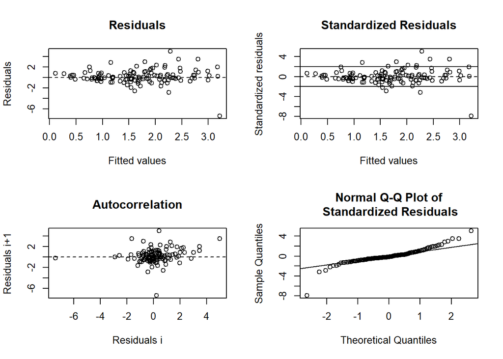

```
##
## ------
##  Shapiro-Wilk normality test
##
## data:  stdres
## W = 0.87421, p-value = 9.388e-09
##
##
## ------
```

```
##
##  Runs Test
##
## data:  as.factor(run)
## Standard Normal = -2.4318, p-value = 0.01503
## alternative hypothesis: two.sided
```

## predict and plot

[figure not shown]

## plotting 2

[figure not shown]

# 341 - Intermountain Semi-desert & Desert

## model selection 1

### summary

- simple model: does not fit
- phi model: does not fit
- phi-alpha model: does not fit

## model selection 2

### summary

- add p model: does not fit
- add s model: does not fit
- add s+p model: does not fit

## plot residuals

```
## [1] "cannot plot residuals"
```

## predict and plot

```
## [1] "cannot plot data with prediction"
```

## plotting 2

# 342 - Intermountain Semi-Desert

## model selection 1

```
## Error in nls(fg_1, data = G_342, start = c(ge = ge.start, A = A.start,  :
##   number of iterations exceeded maximum of 50
## Error in nls(fg_2, data = G_342, start = c(ge = ge.start, phi = phi.start,  :
##   number of iterations exceeded maximum of 50
## Error in nls(fg_3, data = G_342, start = c(ge = ge.start, phi = phi.start,  :
##   number of iterations exceeded maximum of 50
##   model AIC
## 1     1  NA
## 2     2  NA
## 3     3  NA
```

[output not shown]

### summary

- simple model: does not fit
- phi model: does not fit
- phi-alpha model: does not fit

## model selection 2

### summary

- add p model: does not fit
- add s model: does not fit
- add s+p model: does not fit

## plot residuals

```
## [1] "cannot plot residuals"
```

## predict and plot

```
## [1] "cannot plot data with prediction"
```

## plotting 2

# 411 - Everglades

## model selection 1

### summary

- simple model: does not fit
- phi model: does not fit
- phi-alpha model: does not fit

## model selection 2

### summary

- add p model: does not fit
- add s model: does not fit
- add s+p model: does not fit

## plot residuals

```
## [1] "cannot plot residuals"
```

## predict and plot

```
## [1] "cannot plot data with prediction"
```

## plotting 2

# M211 - Adirondack-New England Mixed forest - Coniferous Forest - Alpine Meadow

## model selection 1

```
## Analysis of Variance Table
##
## Model 1: G_obs_TreeInc_MgHaYr ~ (1 + (MEASTIME_avg - 1990) * ge/100) * A * B_plt_t1_MgHa/(k + B_plt_t1_MgHa)
## Model 2: G_obs_TreeInc_MgHaYr ~ (1 + (MEASTIME_avg - 1990) * ge/100) * (1 + phi * DeltaPDSI) * A * B_plt_t1_MgHa/(k + B_plt_t1_MgHa)
## Model 3: G_obs_TreeInc_MgHaYr ~ (1 + (MEASTIME_avg - 1990) * ge/100) * (1 + phi * DeltaPDSI) * (1 - alpha * B_L_prop) * A * B_plt_t1_MgHa/(k + B_plt_t1_MgHa)
##   Res.Df Res.Sum Sq Df  Sum Sq F value    Pr(>F)
## 1   3945     2508.4
## 2   3944     2506.0  1  2.4368  3.8351   0.05026 .
## 3   3943     2478.9  1 27.0573 43.0377 6.066e-11 ***
## ---
## Signif. codes:  0 '***' 0.001 '**' 0.01 '*' 0.05 '.' 0.1 ' ' 1
##   model      AIC
## 1     1 13907.00
## 2     2 13905.17
## 3     3 13864.31
```

```
##
## Formula: G_obs_TreeInc_MgHaYr ~ (1 + (MEASTIME_avg - 1990) * ge/100) *
##     (1 + phi * DeltaPDSI) * (1 - alpha * B_L_prop) * A * B_plt_t1_MgHa/(k +
##     B_plt_t1_MgHa)
##
## Parameters:
##       Estimate Std. Error t value Pr(>|t|)
## ge    0.931749   0.240527   3.874 0.000109 ***
## phi   0.008250   0.005129   1.608 0.107808
## alpha 0.559994   0.081858   6.841 9.08e-12 ***
## A     2.809489   0.124495  22.567  < 2e-16 ***
## k     3.049074   0.514951   5.921 3.47e-09 ***
## ---
## Signif. codes:  0 '***' 0.001 '**' 0.01 '*' 0.05 '.' 0.1 ' ' 1
##
## Residual standard error: 0.7929 on 3943 degrees of freedom
##
## Number of iterations to convergence: 8
## Achieved convergence tolerance: 2.467e-06
```

### summary

- simple model: fits
- phi model: fits
- phi-alpha model: fits

## model selection 2

```
## Analysis of Variance Table
##
## Model 1: G_obs_TreeInc_MgHaYr ~ (1 + (MEASTIME_avg - 1990) * ge/100) * (1 + phi * DeltaPDSI) * (1 - alpha * B_L_prop) * A * B_plt_t1_MgHa/(k + B_plt_t1_MgHa)
## Model 2: G_obs_TreeInc_MgHaYr ~ (1 + (MEASTIME_avg - 1990) * ge/100) * (1 + phi * DeltaPDSI) * (1 - alpha * B_L_prop) * (p * A + ((1 - p) * A * B_plt_t1_MgHa/(k + B_plt_t1_MgHa)))
## Model 3: G_obs_TreeInc_MgHaYr ~ (1 + (MEASTIME_avg - 1990) * ge/100) * (1 + phi * DeltaPDSI) * (1 - alpha * B_L_prop) * (A * B_plt_t1_MgHa^s/(k^s + B_plt_t1_MgHa^s))
## Model 4: G_obs_TreeInc_MgHaYr ~ (1 + (MEASTIME_avg - 1990) * ge/100) * (1 + phi * DeltaPDSI) * (1 - alpha * B_L_prop) * (p * A + ((1 - p) * A * B_plt_t1_MgHa^s/(k^s + B_plt_t1_MgHa^s)))
##   Res.Df Res.Sum Sq Df Sum Sq F value   Pr(>F)
## 1   3943     2478.9
## 2   3942     2473.6  1 5.3093  8.4610 0.003649 **
## 3   3942     2475.6  0 0.0000
## 4   3941     2472.1  1 3.5205  5.6124 0.017882 *
## ---
## Signif. codes:  0 '***' 0.001 '**' 0.01 '*' 0.05 '.' 0.1 ' ' 1
##   model      AIC
## 1     3 13864.31
## 2    3a 13857.84
## 3    3b 13861.09
## 4    3c 13857.47
```

```
##
## Formula: G_obs_TreeInc_MgHaYr ~ (1 + (MEASTIME_avg - 1990) * ge/100) *
##     (1 + phi * DeltaPDSI) * (1 - alpha * B_L_prop) * (p * A +
##     ((1 - p) * A * B_plt_t1_MgHa^s/(k^s + B_plt_t1_MgHa^s)))
##
## Parameters:
##        Estimate Std. Error t value Pr(>|t|)
## ge     0.934915   0.240670   3.885 0.000104 ***
## phi    0.008117   0.005133   1.582 0.113837
## alpha  0.564182   0.081388   6.932 4.83e-12 ***
## A      2.769373   0.124198  22.298  < 2e-16 ***
## k     19.057445   4.509444   4.226 2.43e-05 ***
## p      0.629819   0.066554   9.463  < 2e-16 ***
## s      2.200143   0.763601   2.881 0.003982 **
## ---
## Signif. codes:  0 '***' 0.001 '**' 0.01 '*' 0.05 '.' 0.1 ' ' 1
##
## Residual standard error: 0.792 on 3941 degrees of freedom
##
## Number of iterations to convergence: 18
## Achieved convergence tolerance: 9.732e-06
```

### summary

- add p model: fits
- add s model: fits
- add s+p model: fits

## plot residuals

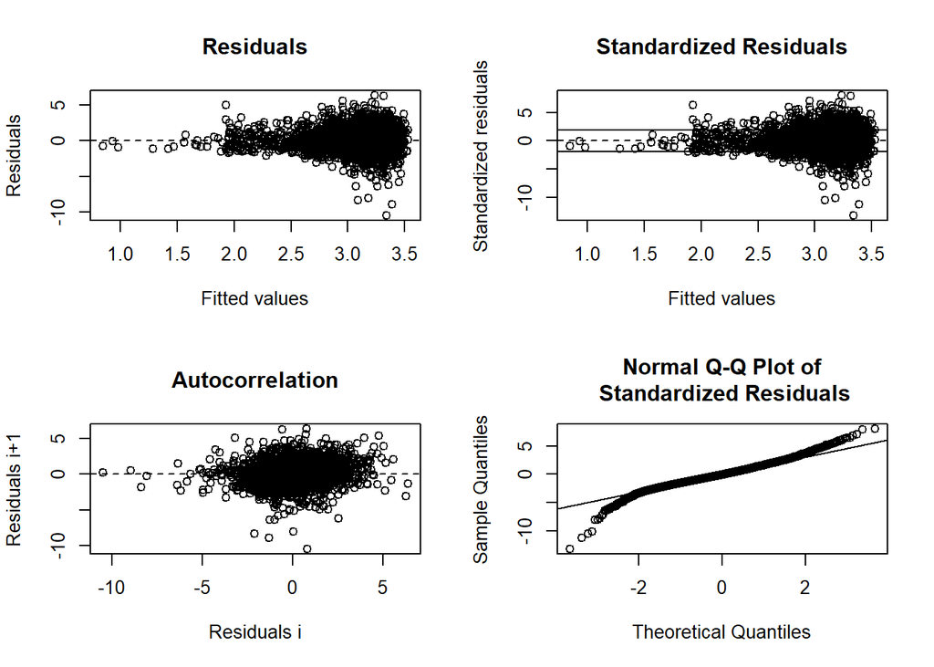

```
##
## ------
##  Shapiro-Wilk normality test
##
## data:  stdres
## W = 0.97581, p-value < 2.2e-16
##
##
## ------
```

```
##
##  Runs Test
##
## data:  as.factor(run)
## Standard Normal = -10.402, p-value < 2.2e-16
## alternative hypothesis: two.sided
```